# Landownership Appears Neither Necessary nor Sufficient for Superior Agricultural Performance in Ghana

Gilbert Addae; Francis Tsiboe; Jacob Asravor

# Abstract

**Keywords**: land tenure; ownership; meta-stochastic frontier; technical efficiency; technology gap; Ghana

**JEL Classification**: Q15, Q12, O13, O55

# Introduction

In many developing economies, higher agricultural productivity raises rural incomes, improve food security, and reduce poverty. For households that depend on farming, productivity determines how much output can be generated from the land, labour, capital, and other resources available to them, with direct implications for farm income and livelihoods. Productivity growth provide an important way through which agriculture support economic development and improve rural welfare [1], [2]. Where land is scarce, productivity gains depend on using existing resources efficiently and adopting improved technologies [3], [4]. Differences in farmers’ ability to do so help explain variation in agricultural productivity and rural development.

The relationship between land ownership and agricultural productivity is often explained through investment incentives. Farmers with secure control over land have greater incentives to undertake investments whose returns extend beyond a single production cycle, such as soil improvement, irrigation, tree planting, and other land enhancing practices. Secure land rights may also encourage the adoption of technologies that require substantial upfront investment or have longer payback periods. Evidence from developing countries suggests that stronger land rights can increase investment and, in some settings, agricultural productivity, although the effects vary across institutional and production contexts [5], [6], [7], [8]. Consistent with this variation, some studies report higher productivity among farmers with secure land rights [9], [10], [11], while others show that the effects depend on tenure arrangements and the conditions under which farmers operate. Secure land rights may encourage investment without generating corresponding productivity gains when farmers face constraints in accessing credit, inputs, technology, or markets [5]. These mixed findings also raise a measurement issue, since land ownership extends beyond whether a farmer owns land. A binary measure overlook differences in documentation, rights to sell, transfer, lease, or pledge land, as well as differences in how land was acquired. Land obtained through purchase, inheritance, family allocation, or customary arrangements provide different levels of security and control over its use.

This institutional variation is particularly important in Ghana, where customary and statutory land tenure systems operate alongside each other. These systems provide farmers with different forms and degrees of security and control over land. Evidence from northwestern Ghana documents substantial variation in customary land rights and tenure security among smallholder farmers [12]. Customary institutions also continue to shape the allocation, use, and transfer of land alongside formal land administration [13], [14]. Such differences in land rights affect farmers’ incentives to invest, adopt technologies, and manage land over time. A binary measure of ownership can therefore conceal institutional differences that are relevant to agricultural production.The way farmers acquire land also shapes the rights and obligations associated with its use. Purchase, inheritance, family allocation, rental, and sharecropping can provide different levels of tenure security, control, and claims over the returns from land based investments. These differences influence how farmers manage land and make production decisions [15], with recent evidence showing variation in agricultural productivity across different modes of land access [16]. Land ownership therefore encompasses different forms of access and control, each with potentially distinct implications for agricultural performance.

Productivity effects of land tenure arrangements also depend on the technology available to farmers and how efficiently they use it. Agricultural performance reflects both the production possibilities provided by available technology and farmers’ ability to convert inputs into output. Farmers therefore differ in productivity because they operate with different technologies, use similar technologies with different levels of efficiency, or both. In production frontier analysis, technology endowment captures differences in the production possibilities available to farmers relative to the best available technology, while technical efficiency captures how effectively farmers use the technology at their disposal [17], [18]. Meta frontier studies apply this distinction to separate technology gaps from efficiency differences across production systems and farmer groups [19], [20], [21]. Evidence from Ghana likewise shows that differences in technology and technical efficiency contribute to variation in agricultural performance across farmers and production environments [22], [23], [24].

Distinguishing between technology endowment and technical efficiency is important for interpreting productivity differences between landowners and non landowners. Higher productivity among landowners may reflect access to better production technology rather than more efficient resource use. Conversely, similar productivity across the two groups may conceal differences in technology and efficiency, as superior technology can offset lower technical efficiency. Aggregate productivity measures therefore cannot establish whether observed differences arise from technology endowment, technical efficiency, or both.

Farmers in sub-Saharan Africa operate with different production technologies and levels of technical efficiency across crops and production systems [22], [23], [25], with technology gaps contributing to differences in agricultural performance [24], [26]. The literature links land ownership to investment, productivity, and farm efficiency [5], [6], [7], [27], [28], [29], including resource use and investment in agricultural production [30], [31], [32]. Yet it remains unclear whether productivity differences associated with land ownership reflect differences in technology, technical efficiency, or both. The owner–non owner distinction also overlooks differences in documentation, transferable rights, and modes of land acquisition that shape how farmers use land.

Ghana offers a useful setting to examine these dimensions because customary and statutory land institutions coexist, with farmers accessing land through diverse arrangements. Customary land rights and security vary substantially across farmers [12], while customary institutions continue to shape land governance alongside formal institutions [13]. These institutional differences mean that land ownership does not represent a uniform set of rights or conditions of use. Examining these differences alongside technology endowment and technical efficiency can provide a clearer account of how land ownership relates to agricultural performance.

Building on this discussion, this paper examines how land ownership relates to agricultural performance in Ghana, focusing on whether landowners and non owners differ in productivity, whether such differences reflect technology endowment, technical efficiency, or both, and whether the relationship varies with documentation, transferable rights, mode of acquisition, and sharecropping intensity. The paper combines statistical matching with a Meta Stochastic Frontier (MSF) framework. Statistical matching compares landowners and non owners with similar observable characteristics, while the MSF framework separates differences in production technology from differences in technical efficiency. This approach builds on the meta frontier literature on producers operating under different technologies [17], [18], [33]. Together, the two methods provide a basis for identifying whether differences in agricultural performance are associated with the technology available to farmers, how efficiently they use it, or both.

The findings indicate that overall performance differs by less than one percentage point between landowners and matched non-owners, yet the two components of that aggregate move in opposite directions. Matched non-owners lie marginally closer to the meta-frontier technology (TGR of 0.856 against 0.847), while landowners attain higher technical efficiency relative to their own frontier (0.485 against 0.479). Neither difference exceeds one percentage point, and the residual meta-frontier efficiency gap of 0.8 percentage points favours non-owners. Ownership is thus associated with neither superior access to technology nor superior use of the technology available, an advantage on one component being accompanied by a shortfall on the other.

These findings have implications for policies concerned with land tenure and agricultural productivity. If ownership alone is not associated with a clear productivity advantage, formalizing ownership or expanding land titling should not automatically be expected to increase agricultural productivity. The productivity effects of stronger land rights may depend on whether farmers can also access credit, agricultural inputs, improved technologies, extension services, and functioning land and output markets. The results on land property-rights interventions suggests that such complementary conditions are important in determining whether stronger rights translate into productive investment and improved agricultural outcomes [5].Land policy should therefore consider not only the formal status of ownership but also the particular rights that farmers can exercise and the broader constraints affecting agricultural production.

The study contributes to the literature by moving beyond the conventional owner–non-owner classification by examining several dimensions of land ownership, including documentation, transferable rights, and mode of acquisition. This provide a detailed representation of the institutional conditions under which farmers operate. Also, it separates technology endowment from technical efficiency when examining agricultural performance which helps to identify whether differences between landowners and non-owners are associated with the production technology available to them or with how efficiently they use that technology. The study also combines statistical matching with a Meta-Stochastic Frontier framework to provide a more comparable assessment of performance differences while accounting for differences in observable characteristics and production technologies.

# Data

## Data sources and construction

Our study draws on five rounds of the GLSS, conducted between 1991/92 (GLSS3) and 2016/17 (GLSS7): a nationally representative, repeated cross-sectional survey built on a two-stage stratified design, in which enumeration areas are selected as primary sampling units and households are then drawn at random within each. We constructed a consolidated dataset of crop-producing households, retaining only farm observations with crop yields between the 2.5th and 97.5th percentiles specific to each crop and survey wave, to limit the influence of outliers.

The dataset comprises 35,185 observations of farm households, each cultivating at least one of the following crops: banana, beans, cashew, cassava, citrus fruits, cocoa, coconut, cocoyam, cotton, eggplant, kenaf, maize, millet, okra, onion, palm, peanuts, pepper, plantain, potato, rice, sorghum, sugarcane, tomato, various vegetables, and yam. We extracted key variables on farmland ownership and use, including tenure status, ownership documentation, mode of land acquisition, and the bundle of rights held, from the agricultural and household modules of each GLSS wave. These variables, however, are not recorded in a uniform format across all rounds, and the consolidated dataset does not include them directly. Therefore, we fall on the original enumeration area, household, and individual identification codes that the dataset retains. Using these identifiers, we reconstructed the tenure variables directly from each round (the plot roster, which records every farm land owned or operated by household members over the preceding twelve months), and merged them into the consolidated dataset. Table S0 documents, for each round, the source variables, the question wording, the response options, and their mapping to the analysis categories. GLSS3 lacks variable and value labels, while GLSS4 lacks value labels. We therefore verified the coding of both rounds against their respective questionnaires rather than inferring it from later rounds.

Land tenure was recorded at the plot level, while production was measured at the farm level. We therefore constructed the treatment in two steps. First, we aggregated plot areas within each tenure category and expressed them as shares of the farmer’s total cultivated area. Second, each farmer was assigned to the category with the largest area share. A farmer was classified as a landowner when formally documented owned plots, undocumented owned plots, or both combined accounted for the largest share of cultivated area; otherwise, the farmer was classified as a non-landowner. The same procedure was used to define the dominant mode of acquisition and bundle of land rights.

Under this construct, 63 percent of farm households in the sample are landowners and the remaining 37 percent operate predominantly on land they do not own. Unless otherwise stated, the term *‘landowner(s)’* in this paper refers to households whose cultivated area is predominantly owned, with or without formal documentation.

The sampling frame also changes across rounds. GLSS3 and GLSS4 were drawn from the 1984 population census enumeration areas, GLSS5 from the 2000 Population and Housing Census, and GLSS6 and GLSS7 from the 2010 Census. The GLSS4 report describes the 1984 frame as “quite old” and “considered inadequate, it being the best available at the time”, and measured land ownership moves by roughly 49 percentage points across the GLSS4/GLSS5 boundary, against about 10 points across the later re-basing. Each round remains representative of the population it sampled, so all five enter the pooled and matched estimation, where every comparison is made within a round; the temporal analysis in Section 5 uses GLSS5 to GLSS7 and sets out the evidence for that restriction.

## Descriptive statistics

Landowners cultivate more land and apply more of every physical input than non-landowners; the trends over time run the other way. Tables 1 and 2 present the unadjusted (pre-matching) summary statistics behind both observations, disaggregated by land ownership status and by trend. The average farmer in the sample is approximately 47 years old, has about 4 years of formal education, and lives in a household of about 5 members. About 26 percent of farmers are female, while the mean dependency ratio stands at 1.40, indicating that each working household member supports more than one dependent. Non-landowners are relatively younger (44.69 years) than landowners (47.80 years), and report slightly more years of education (4.63 years versus 4.04 years). Household size is larger among landowners (5.52 adult equivalents) than non-landowners (4.97), consistent with greater access to family labour within landowning households. Gender composition differs little by ownership status: females make up about 27 percent of non-landowners and 26 percent of landowners, against 26 percent in the pooled sample.

Farm size averages 1.81 hectares, with landowners cultivating larger areas (1.95 hectares) than non-landowners (1.59 hectares). Crop production averages GHS 1,011.52 per hectare across all farmers, with substantial variation across crop types. Overall production growth is slightly higher among landowners (5.04 percent annually) than non-landowners (4.02 percent), yet non-landowners report higher production levels for some staple crops, particularly maize (GHS 3,841 per hectare) and rice (GHS 1,237 per hectare), against GHS 2,279 and GHS 1,213 for landowners. This points to more intensive land use among non-landowners, likely driven by land constraints and the need to maximise output per hectare.

Landowners also apply more of every physical input: more planting material (99.31 kg/ha), fertilizer (194.57 kg/ha), and pesticide (12.55 litres/ha), and heavier reliance on household labour (7.29 adult equivalents) than non-landowners (6.01). Across all farmers, average seed use is 93.94 kg per hectare, fertilizer 162.57 kg per hectare, pesticide 11.45 litres per hectare, and hired labour approximately 20 man-days per hectare. Access to agricultural services and technologies remains limited: only about 1 percent of farmers report using irrigation, 8 percent use mechanised services, and 18 percent have access to credit. Non-landowners report slightly higher access to both credit (21 percent) and mechanization (10 percent) than landowners (16 percent and 7 percent, respectively), though the constraint binds on both groups.

Fertilizer use increased significantly among non-landowners (+5.12 percent annually), while changes among landowners were less consistent. Irrigation use increased for both groups (approximately +10 percent annually), although from a very low base.

Key institutional constraints persist, however. Access to credit declined for both landowners (-3.70 percent) and non-landowners (-3.46 percent), while mechanization use fell sharply over time, particularly among non-landowners (-7.06 percent) compared to landowners (-2.48 percent). Agricultural intensification, in other words, is advancing faster than the credit and mechanization systems meant to support it.

These results show that land ownership status is associated with differences in resource endowment, input use, and production behaviour. Landowners tend to operate larger farms with higher input intensity, while non-landowners appear more land-constrained but relatively more intensive in production, particularly for staple crops. Separating how much of the resulting productivity gap owes to the technology this endowment reaches, as against the efficiency with which it is used, is the task Section 5 takes up.

# Land Tenure Arrangements in Ghana

Between 2012/13 and 2016/17, land tenure in Ghana changed substantially, both in the prevalence of ownership and in the rights associated with it. We first document these changes in aggregate (Table 2) and then examine how they vary across production systems (Tables S1–S4). The distinction is important because land ownership is not a uniform institutional arrangement: farmers differ in whether they own the land they cultivate, how they acquired it, and the rights they hold over it.

At the aggregate level, Table 2 shows a decline in the number of farmers cultivating land they owned. The percentage of farmers working on land they did not own increased from 29.0 percent in 2012/13 to 38.8 percent in 2016/17, while undocumented ownership reduced from 53.9 to 41.7 percent. Documented ownership increased only slightly, from 17.1 to 19.6 percent, leaving the overall distribution shifted away from ownership and toward non-owned land. Also, the share of farmers reporting no ownership rights increased from 56.8 to 66.3 percent. Among the specific rights recorded in the survey, the ability to pledge land as collateral declined from 3.5 to 2.2 percent, while the ability to sell land fell from 6.4 to 2.9 percent. The share of farmers reporting both rights also declined, from 33.3 to 28.6 percent. Therefore, the decline in ownership was accompanied by a reduction in the frequency of the specific rights through which land ownership can facilitate transfer or access to credit.

Family and village allocation remained the dominant means of accessing land, accounting for about 61 percent of cases, while free access declined slightly from 17.9 to 14.8 percent. Sharecropping, by contrast, increased from 11.9 to 16.0 percent, reflecting the continued importance of flexible arrangements within Ghana’s largely customary land system. Rental and purchase remained uncommon, with purchases accounting for only 2.2 percent at the end of the period. Thus, farmers continued to obtain land mainly through family and community-based arrangements rather than market transactions. The growing importance of sharecropping is also evident in the extent of land cultivated under the arrangement. The share of farmers with no sharecropped land fell from 83.0 to 80.5 percent, while those cultivating 1-49 percent of their land under sharecropping increased from 5.9 to 9.0 percent. The share cultivating 50-100 percent remained broadly stable at around 11 percent, suggesting that the increase was concentrated among farmers with moderate reliance on sharecropping.

These changes in land access and the growing role of sharecropping also vary considerably across crops (Tables S1–S4). Undocumented ownership is particularly common among staple crops such as beans, sorghum, millet, and rice, accounting for 63.0, 62.6, 57.7, and 58.2 percent, respectively. Documented ownership, in contrast, is more prevalent among cocoa, banana, and plantain producers, at 26.4, 24.3, and 21.9 percent. Non-ownership shows a related but distinct pattern: banana, cocoyam, and cassava have the highest shares of farmers cultivating land they do not own, at 42.1, 40.9, and 40.6 percent, respectively, compared with just 20.2 percent for sorghum and 22.3 percent for millet. These differences indicate a substantial variation in how farmers access and control land across production systems, with some crops relying more heavily on informal or shared arrangements than others.

The differences across crops extend beyond ownership status to how land is acquired and the rights attached to it. Family and village allocation accounts for 61.0 percent of farmers overall and is particularly common among millet, sorghum, and rice producers, at 81.7, 81.9, and 75.7 percent, respectively. Free access is more prevalent among peanut and yam producers, at 22.9 and 21.9 percent, while sharecropping is more common among banana, cocoa, and palm producers, at 30.8, 28.1, and 26.2 percent. Purchase and rental remain relatively uncommon across production systems, pointing to the limited role of market-based land acquisition. A similar pattern emerges for ownership rights: 65.0, 65.2, and 67.6 percent of millet, sorghum, and bean farmers, respectively, report no ownership rights, compared with 39.9 percent of cocoa and 34.0 percent of palm producers reporting ownership rights that include the ability to pledge or sell land. These differences show that both access to land and the rights attached to it vary systematically across production systems.

Sharecropping shows marked differences across production systems. Although 82.1 percent of farmers do not cultivate any sharecropped land, the arrangement is more prevalent among banana, cocoyam, and palm producers, with 27.1, 23.9, and 23.2 percent, respectively, cultivating 50–100 percent of their land under sharecropping. By contrast, millet, sorghum, and peanut producers show little reliance on intensive sharecropping, with 98.1, 98.5, and 96.6 percent cultivating no sharecropped land. These differences are relevant for interpreting the productivity implications of tenure because ownership and sharecropping may shape different aspects of farm decision-making. Evidence from Ghana’s cocoa sector, for example, shows that family land title is more closely associated with fertiliser use and land investment, whereas sharecropping is more strongly associated with the adoption of hybrid seedlings [31]. Tenure arrangements may therefore influence not only the extent of investment but also the choice of production technologies, meaning that a single ownership measure may conceal important differences in farmers’ incentives.

The aggregate and crop-level evidence reveals substantial heterogeneity in how farmers access and control land. Ownership declined over the study period, accompanied by a reduction in reported ownership rights and greater reliance on sharecropping. These changes also differed across production systems: cocoa, palm, banana, and plantain were more likely to be associated with documented ownership and transferable rights, whereas millet, sorghum, beans, and other staples relied more heavily on customary and undocumented arrangements. These patterns alone, however, do not indicate whether particular tenure arrangements confer productivity advantages. Evidence from West Africa suggests that the relationship between tenure and investment varies with the type of investment, the measurement of tenure, and the empirical approach used to identify the relationship [7].

# Methods

## Conceptual framework

Land ownership may affect farm performance through two distinct margins that an aggregate comparison cannot distinguish. The first is technical efficiency (TE), which captures how effectively farmers use the technology available to them. The second is the technology gap ratio (TGR), which captures how close the technology available to a farmer is to the best technology attained by any farmer in the sample [6], [34]. The potential effect of ownership on TE arises primarily through farmers’ control over land. Farmers who expect to cultivate the same plots over longer periods may have stronger incentives to maintain soil fertility, time farm operations appropriately, and supervise labour than those operating under temporary or contested tenure. Farmers without ownership, however, may respond to insecure or short-term tenure by intensifying inputs that are under their direct control, potentially narrowing the efficiency advantage that ownership would otherwise provide [9], [10], [35].

Beyond these effects on how efficiently existing technology is used, ownership may influence the technology farmers are able to access. Secure ownership can facilitate investment by extending the horizon over which farmers can recover the returns to land-improving investments and by improving access to credit. These channels can encourage the adoption of improved seeds, machinery, and other productivity-enhancing technologies [36], [37]. In contrast, insecure tenure can discourage investment because farmers face greater uncertainty over whether they will retain the benefits of future returns, while the absence of acceptable collateral may further restrict access to credit [38], [39]. Ownership may also improve access to extension services, market information, and other inputs that expand the technology available to farmers, independently of credit constraints [23], [25], [40]. These mechanisms imply that ownership may affect both the efficiency with which farmers use existing technology and the technology frontier they can access. We therefore hypothesise that (H1) land ownership is associated with higher meta-frontier technical efficiency (MTE), and (H2) that this advantage operates primarily through the technology margin, reflected in a higher TGR rather than a higher TE.

The extent to which these mechanisms operate, however, depends on what ownership means in practice. Ownership is not a uniform institutional condition, and the measures used to capture it may reflect different dimensions of farmers’ actual tenure security. Documentation is one such dimension. Where security derives from customary authority and social relationships rather than formal documentation, an undocumented farmer may enjoy protection comparable to that of a documented owner and therefore face similar incentives to invest [32]. The rights attached to ownership provide another distinction. The ability to pledge or transfer land gives ownership financial and economic value, whereas an owner without these rights may have limited access to the credit and investment channels through which ownership is expected to affect technology. The mode of acquisition is also relevant, since purchased, rented, inherited, and family-allocated land may provide different degrees of security and different investment incentives even among farmers with similar documentation status [5], [15], [41]. Finally, the extent to which ownership translates into productivity gains may vary with farmer and production characteristics, including gender, age, education, crop characteristics, and the functioning of local land and credit markets [11], [12], [14], [42]. These considerations motivate our examination of ownership not only as an aggregate status, but also through its documentation, associated rights, and mode of acquisition.

## Meta-stochastic frontier analysis

A raw comparison between landowners and non-landowners conflates two things that are conceptually separate: how good the technology available to each group is, and how efficiently each group uses whatever technology it has. The meta-stochastic frontier (MSF) framework exists to pull these apart, comparing farm performance both within a tenure group and across groups that may not share the same production technology at all. The approach has an established applied record in agriculture, including Ghanaian maize [19], Ethiopian cereals [20], and Bangladeshi dairy systems [21], each using group-specific frontiers and metatechnology ratios to make the same separation. Table S5 reports the full set of frontier estimates obtained here.

The construction follows the two-step MSF approach [33] and proceeds in three stages. A stochastic frontier is fitted separately within the landowner group and within the non-landowner group, and each farmer’s technical efficiency (TE) is read off against their own group’s frontier, a measure of how well they convert inputs into output relative to others farming under the same tenure status. The two frontiers are then pooled into a single meta-frontier: the best production technology attained by any farmer in the sample, regardless of tenure. Each group’s shortfall below that shared benchmark is its technology gap ratio (TGR) [17]. Multiplying a farmer’s TE by their group’s TGR yields meta-frontier technical efficiency (MTE), performance judged against the best technology in the whole sample rather than only against the farmer’s own group. Because TE and TGR are estimated as separate quantities before being multiplied together, an MTE gap between landowners and non-landowners can be traced to whichever of the two, unequal technology or unequal efficiency, is actually responsible, rather than left as one undifferentiated number.

Within a tenure group we treat the production technology as shared across all farmers in that group, so that variation in management, not variation in technology, is what spreads farmers across different points along the group’s frontier. Some farmers land below the frontier because of inefficiency or a one-off setback; others can appear to sit above it, not because their technology is better but because a favourable shock happened to raise their output that period. Prior studies of Ghanaian agricultural production using GLSS data have fitted both Cobb-Douglas and Translog specifications [24], [25], [26]; a likelihood ratio test here rejects Cobb-Douglas at the 1 percent level, so we proceed with the Translog. Left uncorrected, the Translog estimates violate monotonicity and quasi-concavity, so we impose monotonicity directly and check quasi-concavity after estimation using a standard three-step correction; once corrected, monotonicity holds for 44 to 100.0 percent of observations and curvature for 20 to 58 percent, depending on the frontier (Table 3). The group-specific frontier for group $j$ is therefore a Translog:

$f^{j}\left( x_{\text{ijt}} \right) = \ln y_{\text{ijt}} = \beta_{0j} + \sum_{k}^{}{\beta_{\text{kj}}\ln x_{\text{kijt}}} + \frac{1}{2}\sum_{s}^{}{\sum_{k}^{}{\beta_{\text{skj}}\ln x_{\text{kijt}}\ln x_{\text{sijt}}}} + \beta_{h}h_{\text{ijt}} + v_{\text{ijt}} - u_{\text{ijt}}$

$u_{\text{ijt}}\sim N^{+}\left\lbrack 0,exp\left( w_{\text{ijt}}\alpha \right) \right\rbrack$, $v_{\text{ijt}}\sim N\left( 0,\sigma_{\text{vj}}^{2} \right)$ (1)

Here $y_{\text{ijt}}$ is the value of crop output for farmer $i$ in group $j$ at survey $t$; each $x_{\text{kijt}}$ is an input, land, planting materials, family labour, hired labour, fertilizer, or pesticide, used by farmer $i$; and $h_{\text{ijt}}$ collects production shifters, agroecological zone and crop composition. Group membership $j$ is defined by land ownership status ($j=1$ for landowners, $j=0$ for non-landowners), so ownership never appears in Equation (1) as its own regressor; instead it determines which farmers are grouped together to estimate which frontier, which is exactly what makes it possible to recover the technology difference and the efficiency difference attributable to ownership as two separate quantities rather than one blended figure. The terms $u_{\text{ijt}}$ and $v_{\text{ijt}}$ stand for inefficiency and idiosyncratic noise, respectively.

We take the inefficiency term to be half-normal. This is a practical choice as much as a theoretical one: more flexible alternatives, exponential, generalized exponential, Rayleigh, and two-sided Laplace among them, would not converge reliably in the subgroup estimations. We make no advance claim that the aggregate result is insensitive to this choice; Section 5 instead reports how far the estimates actually move under each alternative distribution. Following earlier GLSS-based work [24], [25], [26], [43], the inefficiency variance $\sigma_{u_{\text{ijt}}}^{2} = \exp\left( w_{\text{ijt}}\alpha_{j} \right)$ is allowed to depend on farmer characteristics (age, gender, education), institutional variables (credit access, mechanization, extension), crop diversification, and a fixed effect for agroecological zone. The institutional variables in particular have been shown to predict farmers’ uptake of yield-enhancing practices [40], and so plausibly shift the distribution of managerial performance rather than only its mean. The noise term is standard normal, $v_{\text{ijt}}\sim N\left( 0,\sigma_{\text{vj}}^{2} \right)$ [44].

A farmer’s efficiency relative to their own group’s frontier is then $\text{TE}_{\text{ijt}} = \ E\left\lbrack \exp\left( - u_{\text{ijt}} \right)|{\widehat{\varepsilon}}_{\text{ijt}} \right\rbrack$ (2)

The second stage pools predicted output across both tenure groups to fit a meta-frontier enveloping the two group-specific frontiers:

$f^{M}\left( x_{\text{ijt}} \right) = \ln{\widehat{y}}_{\text{ijt}} = \beta_{0M} + \sum_{k}^{}{\beta_{\text{kM}}\ln x_{\text{kiMt}}} + \frac{1}{2}\sum_{s}^{}{\sum_{k}^{}{\beta_{\text{skM}}\ln x_{\text{kiMt}}\ln x_{\text{siMt}}}} + \beta_{h}h_{\text{ijt}} - u_{\text{Mijt}}$ (3)

The meta-frontier inefficiency term $u_{\text{iM}}\sim N^{+}\left( 0,\exp\left( w_{i}\alpha_{M} \right) \right) > 0$ guarantees $f^{j}\left( x_{\text{ijt}} \right) \leq f^{M}\left( x_{\text{ijt}} \right)$: no group’s frontier can lie above the meta-frontier by construction. The ratio of the two therefore gives the Technology Gap Ratio (TGR):

$\text{TGR}_{\text{ijt}} = \frac{f^{j}\left( x_{\text{ijt}} \right)}{f^{M}\left( x_{\text{ijt}} \right)} = e^{- u_{\text{iM}}} \leq 1$ (4)

A TGR close to one means a group’s technology is nearly as good as the best in the sample; multiplying it by TE gives Meta-Technical Efficiency (MTE), a farmer’s performance measured against that sample-wide best rather than only against their own group:

$\text{MTE}_{\text{ijt}} = \ f^{j}\left( x_{\text{ijt}} \right)\left\lbrack f^{M}\left( x_{\text{ijt}} \right)e^{v_{\text{ijt}}} \right\rbrack^{- 1} = \text{TGR}_{\text{ijt}} \times \text{TE}_{\text{ijt}}$ (5)

Every parameter is estimated by maximum likelihood. Input elasticities come from the first partial derivatives of the fitted frontier evaluated at mean input levels, and returns to scale from summing those elasticities.

## Identification Strategy and Matched Sample Construction

Landowners and non-landowners are not randomly assigned to tenure status, making a direct comparison potentially confounded by differences in farmer, household, and production characteristics. We therefore use matching to construct a balanced sample of landowners and non-landowners with similar observable characteristics. Each landowner is matched one-to-one with the most similar non-landowner based on observed farmer, household, and production characteristics. To ensure that matches are drawn from comparable institutional and geographic settings, matching is restricted to farmers within the same gender, GLSS wave, region, agroecological zone, and rural or urban setting. The resulting differences in TGR, TE, and MTE should therefore be interpreted as conditional associations within the matched sample rather than causal effects of land ownership.

The covariates used for matching capture farmer demographics, household characteristics, and production structure. They include age, education, marital status, religion, ethnicity, and relationship to the household head; household size, dependency ratio, and female share; crop diversification; and the shares of cultivated land allocated to different crops. These variables are intended to balance observable differences that may be associated with both tenure status and farm performance. Matching, however, cannot account for unobserved factors such as inherited land quality, soil characteristics, household wealth, proximity to markets and roads, or farmers’ positions within customary institutions. Addressing such sources of selection would require an exogenous source of variation in land ownership, such as an instrument that predicts tenure status without directly affecting farm performance, which is not available in the GLSS.

The interpretation of the matching exercise (Table S6) also depends on how tenure status is measured. Farmers are classified as landowners or non-landowners using the cultivated-area rule described in Section 2, based on their reported tenure status across plots. Such self-reported measures may not fully capture effective ownership because formal and customary conceptions of land ownership do not necessarily coincide in Ghana. Much agricultural land is governed by customary arrangements that may provide secure, heritable, or transferable use rights without formal documentation, making the reported ownership status sensitive to how respondents interpret the survey question. This is particularly relevant across GLSS rounds, where the wording and probing procedures differ; for example, GLSS3 instructed interviewers to probe specifically for a title deed. Previous evidence suggests that self-reported tenure measures can contain information not captured by administrative records, but may also be subject to reporting error [45], [46]. We therefore interpret the matching estimates as comparisons of farmers with similar observable characteristics rather than as corrections for measurement error.

Because the matching variables combine continuous and categorical characteristics, we evaluate several measures of closeness rather than imposing a single distance metric. One-to-one matching is conducted using Euclidean distance, scaled Euclidean distance, propensity scores estimated with Logit, Probit, complementary log-log, and Cauchit links, Mahalanobis distance [47], and robust Mahalanobis distance [48]. Balance is assessed using standardized mean differences, variance ratios, and Kolmogorov–Smirnov statistics, with values close to zero for standardized differences and Kolmogorov–Smirnov statistics and values close to one for variance ratios indicating better balance [49], [50]. The alternative procedures produce similar standardized differences but differ in variance balance. Robust Mahalanobis matching provides the closest variance ratios to one while remaining among the strongest methods on the other balance measures and is therefore used for the main analysis. Figure S1 presents the balance achieved by each matching procedure across all covariates, allowing the choice to be assessed directly.

The results are not sensitive to this particular matching choice. The robustness analysis in Section 5 repeats the estimation using alternative distance measures and propensity-score specifications (Figure S2). None changes the aggregate TGR, TE, or MTE estimates by more than approximately one percentage point relative to the main specification. Because the estimated ownership differences are themselves small, however, changes of this magnitude can cause individual estimates to cross zero. We therefore interpret the aggregate comparison as evidence of near-parity between landowners and non-landowners rather than relying on the direction of a small residual difference.

The five GLSS rounds are also treated separately in the estimation rather than pooled into a single cross-section. Differences in sampling frames, questionnaire wording, and fieldwork implementation make a pooled specification potentially misleading and could impose a common production technology and inefficiency structure over periods in which both may have changed. We therefore estimate the MSF model separately within each survey wave, allowing the production frontier and inefficiency structure to vary over time. TE, TGR, and MTE are then averaged across waves to summarise the ownership gap over the study period. This approach also ensures that each comparison between landowners and non-landowners is made within the same survey-specific institutional and measurement environment.

The matching design balances farmers on observed characteristics but does not eliminate potential selection on unobserved factors, such as land quality or other characteristics that may jointly influence tenure and productivity. The ownership indicator also represents the dominant tenure arrangement based on cultivated-area shares and therefore does not capture differences in the duration, intensity, or security of individual land claims. These considerations mean that the resulting TGR, TE, and MTE differences are interpreted as conditional associations rather than causal effects of land ownership. The household sampling weight (WeightHH) is incorporated into the frontier estimation, matching procedure, and jackknife inference to account for the two-stage stratified sampling design. The TE, TGR, and MTE estimates therefore retain the population-representative structure of the underlying GLSS samples. Tables 1 and 2 are reported without weights because they describe the composition of the analytical sample rather than estimate population means. Standard errors are obtained using a jackknife procedure that resamples enumeration areas. For each survey wave, 100 resamples are constructed by omitting one enumeration area at a time, and the complete estimation procedure including frontier estimation, matching, and meta-frontier estimation, is repeated for each resample. The dispersion of the resulting estimates provides the reported standard errors while preserving the primary sampling-unit structure of the survey.

# Results and discussions

The results that follow separate two things an aggregate productivity comparison necessarily conflates: which production technology a farmer can reach, and how efficiently that technology is used once reached. Ownership bears on both, and in opposite directions. Table 3 carries both the specification diagnostics, with which this section opens, and the input elasticities on which everything after them rests. Table 4 disaggregates the ownership gap by documentation, by rights, and by mode of acquisition, where the opposing directions are sharpest. Figure 1 shows what ownership does to input use once farmers are matched, and Figure 2 asks whether any of it has moved across twenty-five years. Figures 3 and 4 test whether the aggregate finding survives disaggregation by farmer characteristics, crop, and region. Note S1 treats the covariates driving inefficiency itself, which we regard as background to the ownership comparison rather than part of it.

The sign convention is uniform across these exhibits: every gap is reported as some ownership minus no ownership, so a positive value places landowners ahead of their matched counterparts and a negative value places them below. The direction is restated at each exhibit.

## Model diagnostics

After imposing the monotonicity and curvature conditions required for a well-behaved production function, the estimated Translog frontiers satisfy these conditions to varying degrees across the specifications. The group-specific frontiers perform better than the naïve national frontier, which satisfies monotonicity at only 44 percent of observations and curvature at 20 percent. The meta-frontier satisfies monotonicity for the large majority of observations, more than 99 percent, though curvature holds for 54 to 58 percent. Although the conditions are not satisfied at every observation, the estimated input elasticities are positive across the specifications, indicating that the production functions exhibit the expected economic behaviour on average. Table 3 presents the estimated elasticities and the corresponding regularity checks.

Three tests were then used to assess whether the data support the one-sided error structure underlying the stochastic frontier model: the OLS residual skewness test proposed by Schmidt and Sickles [51], the skewness test of [52], and the generalized likelihood-ratio test for technical inefficiency [53]. All three tests reject the null hypothesis of no one-sided inefficiency, providing support for the stochastic frontier specification. The likelihood-ratio test for the null hypothesis that landowners and non-landowners operate under the same production frontier is also rejected. This result indicates that the two groups operate under heterogeneous production technologies and supports the use of separate group-specific frontiers within the MSF framework.

The estimated variance decomposition provides further evidence that technical inefficiency is an important source of variation in crop output. The mean value of $\gamma=\sigma_u^2/\sigma^2$ is 0.711 for landowners and 0.770 for non-landowners. Both values exceed one-half, indicating that a substantial proportion of the unexplained variation in output is associated with technical inefficiency rather than the stochastic error component. The corresponding $\gamma$ estimates for the meta-frontier are 0.811 for the matched sample and 0.856 for the unmatched sample. The higher meta-frontier values indicate that inefficiency remains an important source of variation when farmers are evaluated against the common technological benchmark. This variance decomposition should, however, be distinguished from the technology gap ratio (TGR), which captures the distance between each group’s production technology and the meta-frontier. Table S7 reports the estimated determinants of technical inefficiency, while Note S1 provides further details on its interpretation.

## Output elasticities

Table 3 shows that the elasticities of total crop output with respect to all factor inputs are positive and statistically significant at the 1 percent level across the estimated frontiers, consistent with previous evidence on Ghanaian agriculture [23], [24], [25], [43]. Land has the largest elasticity in all specifications, followed by family labour and planting materials. Hired labour, pesticide, and fertilizer are smaller, with fertilizer the smallest in every specification and the order of hired labour and pesticide varying between them. The relatively large elasticity of land indicates that changes in cultivated area are associated with substantially larger changes in output than comparable changes in the other inputs.

Differences emerge when the elasticities are compared by tenure status. Under the matched meta-frontier, family labour, planting materials, and hired labour have higher elasticities for landowners than for non-landowners, with gaps of 0.050, 0.005, and 0.013, respectively. These differences are statistically significant under jackknife inference, indicating that the same marginal increase in these inputs is associated with greater additional output among landowners. Fertilizer and pesticide show the opposite pattern, with marginally higher elasticities among non-landowners by 0.002 and 0.004, respectively. Ownership therefore does not uniformly increase the productivity of all inputs. Rather, the differences are concentrated among inputs closely tied to the seasonal use and management of land, while non-landowners obtain somewhat greater marginal returns from purchased inputs that can be adjusted more readily within the production cycle.

One possible explanation for the observed differences is variation in crop composition. If landowners were disproportionately engaged in crops with higher production potential, their greater elasticities could reflect crop choice rather than differences in the productivity of inputs. The crop-specific estimates provide little evidence for this explanation. Under the matched meta-frontier, none of the thirteen crop coefficients differs significantly between landowners and non-landowners at the 5 percent level, with the exception of maize among landowners. The observed differences in input elasticities and returns to scale therefore provide little evidence of being systematically driven by differences in crop composition.

## Technology differentials and technical efficiency

Table 3 also reports the level of technological endowment among farmers in Ghana by land ownership status, measured by technology gap ratios (TGRs). The matched-sample results reveal a statistically significant but economically small difference between landowning and non-landowning farmers. Specifically, farmers without land ownership exhibit a slightly higher TGR (0.856) compared to landowners (0.847), indicating that non-landowners are marginally closer to the meta-frontier in terms of access to best-practice production technologies. This shows that both groups achieve approximately 85 percent of the potential output attainable under optimal technology, suggesting that technology access is broadly comparable across ownership categories, with only a minor advantage for non-landowners.

Classical land tenure models indicate that ownership enhances productivity by strengthening property rights, reducing tenure insecurity, and incentivizing long-term investment [8], [10], [56], [57]. However, the findings suggest that such advantages may not fully materialize in contexts where access to land can be secured through alternative arrangements. In Ghana, the increasing prevalence of rental, borrowing, and sharecropping systems appears to weaken the direct link between ownership and access to improved production technologies [12], [42], [58], [59], thereby contributing to the observed convergence. The gap we recover is also far smaller than the unmatched literature reports: estimating a metafrontier on a single round of these data without adjusting for selection, Asante et al. [60] place deed-holders roughly fourteen percentage points closer to the metafrontier than non-owners. The two estimates are not directly comparable, since they differ in the number of rounds pooled, in how ownership is categorised, and in the treatment of selection. But the direction of the discrepancy is what a matched design would predict if the raw advantage reflects who comes to hold land as much as what holding it confers. That reading should not be pressed too far. Ngango and Hong [28] combine propensity-score matching with a selection-corrected frontier for Rwandan maize and still find technical efficiency consistently higher for owners in every specification, so matching does not invariably dissolve the ownership advantage. A useful sense of scale comes from the same GLSS-based machinery applied to a different margin: Tsiboe et al. [61] report that the technology sets employed by farmers with disabilities in Ghana are about 11 percentage points less productive than those of farmers without disabilities, with negligible differences in technical efficiency between them, leaving a 9.5 percentage point shortfall in crop production. Where a real barrier to technology access operates, this approach registers a gap several times larger than ownership produces, which is the standard against which the sub-percentage-point ownership gap reported here should be judged.

When efficiency is evaluated relative to each group-specific frontier, a slightly different pattern emerges. The estimates of pure TE indicate that landowners operate at a marginally higher efficiency level (0.485) compared to non-landowners (0.479), with the difference being statistically significant but quantitatively small, indicating that while both groups utilize available technologies with similar effectiveness, landowners possess a slight advantage in converting inputs into output, potentially reflecting stronger control over fixed inputs and more stable production conditions [27].

The results on overall performance, indicate that non-landowners achieve a slightly higher MTE (0.414) compared to landowners (0.407), with the difference being statistically significant, suggesting that the technological advantage observed among non-landowners outweighs the efficiency advantage held by landowners, resulting in a marginally higher overall performance for farmers without ownership.

These findings reveal a structural trade-off between access to production technologies and the efficiency with which they are utilized, the two channels through which property rights are held to operate on farm performance [6], [34]. While landowners tend to exhibit slightly higher efficiency likely due to stronger control over land and production decisions, non-landowners appear to benefit from relatively better access to available technologies. One important mechanism underlying this pattern is the role of land rental and sharecropping markets in reallocating land toward more productive and commercially oriented farmers. Such arrangements enable efficient producers without ownership to access land and participate actively in agricultural production, thereby narrowing productivity differences across tenure categories. At the same time, ownership may facilitate better planning horizons and input control, but these advantages can be offset by constraints such as limited liquidity, risk aversion, and suboptimal input allocation. As a result, ownership status influences productivity through multiple and sometimes offsetting channels.

This finding is consistent with empirical evidence from Ghana showing that productivity differentials across land ownership categories are largely driven by variations in input use, scale, and technical efficiency rather than ownership status per se, echoing evidence that productivity differences reflect broader structural and institutional conditions rather than ownership as such [29]. In this context, ownership status is not independently associated with performance outcomes once resource allocation and production decisions are taken into account. Thus, the slightly higher performance of non-landowners observed in the meta-frontier results likely reflects more efficient factor allocation and stronger engagement with market-oriented production systems. The observed convergence can be attributed to broader institutional and structural transformations within Ghana’s agricultural sector. Policy interventions such as the Food and Agriculture Sector Development Policy (FASDEP I and II) and fertilizer subsidy programs have expanded access to agricultural inputs and services beyond landowning households [62]. At the same time, the expansion of land rental and sharecropping arrangements has improved access to land for non-owners, allowing them to participate more actively in agricultural production [63], [64]. These developments have reduced the extent to which ownership status constrains access to technology, contributing to the observed patterns.

Despite this progress, persistent structural constraints continue to limit productivity improvements for both groups. Weak extension systems, limited access to formal credit, and inadequate irrigation infrastructure constrain the adoption and effective use of improved technologies irrespective of ownership status, consistent with evidence that input access, functioning markets, and institutional support bear more on productivity than ownership status alone [11], [14]. Moreover, the predominance of informal and fragmented land tenure systems may still discourage long-term investment in productivity-enhancing technologies, even among landowners [65].

## Tenure form and the direction of the ownership gap

The aggregate comparison treats ownership as a single binary, but ownership is not one thing. A farmer may hold a deed, may hold enforceable rights to sell or pledge the land, and may have obtained it by purchase, rent, inheritance, or village allocation, each a different institutional fact with different consequences. Table 4 disaggregates the matched-sample gap along three such dimensions, documentation, specific rights, and mode of acquisition, with sharecropping intensity examined as a further breakdown within acquisition mode. Our primary specification defines ownership broadly, documented or not. Refining the classification does not make the disparities in technology access and productivity disappear, but it does show that they do not run in a single direction, and that turns out to be the substantive result rather than a complication.

Mode of acquisition splits the two channels apart more sharply than either documentation or rights does. Table 4 reports the matched-sample gap as some-ownership minus no-ownership within each category, so a positive entry places landowners ahead. On land accessed free of charge, landowners perform at least as well as their matched counterparts on all three metrics (TGR +2.9, TE +1.3, MTE +2.2 percentage points).

Within every other acquisition mode, landowners remain closer to the meta-frontier technology, with TGR gaps ranging from +1.4 to +6.5 percentage points, but they are substantially less efficient in using it. The efficiency shortfall is largest on purchased land (TE −11.2, MTE −6.8 percentage points) and rented land (TE −8.3, MTE −7.0), and smaller but still sizeable on family- or village-distributed land (TE −6.7, MTE −5.3). Sharecropping shows the same pattern at a finer grain, the landowner MTE shortfall widening from 2.3 percentage points at low intensity to 3.8 points at high intensity. These efficiency shortfalls are not small by the standard this paper has already set. They are comparable to, and on purchased land larger than, the 11-point gap that the disability comparison earlier in this section treats as evidence of a genuine barrier to technology access. Aggregating ownership into a single binary variable averages this away. The technology-access advantage landowners hold on land acquired by purchase or rental is offset by a real efficiency cost, of a size the paper’s own benchmark would call substantial, and disaggregating by acquisition mode is what makes that cost visible.

The size and direction of the ownership gap is therefore a property of which tenure dimension is examined, not a stable feature of ownership itself. An ownership status that mattered in the way the titling literature supposes would not reverse sign, and vary this much in size, depending on whether it is measured by documents, by rights, or by mode of acquisition, so this instability is itself evidence for the paper’s central claim.

The Ghanaian evidence suggests why it might arise. Goldstein and Udry [32] show that security over a plot follows the cultivator’s standing in the local political hierarchy rather than any attached document, so documentation and effective control need not coincide, and the tenure dimensions examined here need not move together [15].

## Robustness of main findings

If the near-parity result reported throughout this section depends on one arbitrary modeling choice, it is an artifact rather than a finding. Re-estimating the aggregate comparison under eighteen alternatives to the main specification, spanning six dimensions, tests that possibility directly. The production function is tested under Cobb-Douglas in place of Translog. The distributional assumption on the inefficiency term is tested against four alternatives to the half normal, exponential, generalized exponential, Rayleigh, and truncated skewed Laplace. The method for calculating observation-level TGR, TE, and MTE scores is tested against Jondrow et al. and the conditional model, in place of Battese and Coelli. The aggregation rule is tested against the simple mean and the median, in place of the weighted mean. The sample is tested against seven alternative distance metrics and propensity-score links, and against the unmatched sample, in place of robust Mahalanobis distance. And the imposition of the theoretical regularity conditions on the frontier is tested directly, with and without. Figure S2 reports every alternative as the difference in mean scores between landowners and non-landowners, so a positive value places landowners ahead, against main estimates of TGR −0.81, TE +0.62, and MTE −0.79 percentage points.

Setting aside the distributional assumption and the unmatched sample, both examined separately below, the remaining thirteen alternatives leave the result essentially unchanged. Every estimate of every metric falls between -1.60 and 1.09 percentage points, and none moves any metric more than 1.12 points from its main value. Functional form, efficiency estimator, aggregation rule, distance metric, and the imposition of regularity conditions all yield the same conclusion. Ownership is associated with a difference in technology access and in efficiency of at most about one percentage point in either direction, and this ceiling does not shift across specifications.

The direction of that difference proves less stable, though the instability is arithmetic rather than substantive. Because the main gaps are themselves smaller than one percentage point, movements far too small to matter economically are still large enough to cross zero. Four of these thirteen alternatives reverse the sign of a metric. The Cauchit propensity-score sample puts the TGR gap at +0.15 points, median aggregation puts the MTE gap at +0.21, relaxing the regularity conditions puts the TE gap at −0.09, and the complementary log-log sample puts it at −0.51. Three of these reversals are indistinguishable from zero under jackknife resampling, which reads as the gap vanishing rather than changing direction. The fourth is distinguishable from zero. The complementary log-log estimate reverses the TE gap significantly on its own terms. The aggregate result is therefore best reported as near-parity, with no sign assigned to it. Which group holds the residual fraction of a percentage point is not identified by these data, so that sign carries no standing as a finding.

The assumed distribution of the inefficiency term is the one dimension in which the movement is both large and sign-changing, though two distributions that appear similar in Figure S2 warrant separate treatment. Under the exponential distribution, all three metrics reverse precisely. TGR moves to +6.76 points against a main estimate of −0.81, TE to −1.53, and MTE to +2.17, each with a jackknife t-ratio above eleven in absolute value. This constitutes a competing estimate rather than noise, and it is an order of magnitude larger than anything the other five dimensions produce. The generalized exponential distribution moves in the opposite direction, to −8.78 points on TGR, but its standard errors are wide enough that neither its TGR nor its TE estimate is distinguishable from zero, so it widens the interval without contributing a competing point estimate of its own.

The unmatched sample serves a different purpose within this panel. Rather than testing whether the result holds up under alternative specifications, it tests where the raw ownership advantage originates. Without matching, landowners lead on all three measures, by +0.62 points on TGR, +2.31 on TE, and +1.47 on MTE, each precisely estimated. Matching removes roughly three-quarters of the TE lead and reverses the other two, leaving the main estimates reported above. This contrast represents the paper’s selection argument in miniature. Most of the raw ownership advantage is attributable to which farmers come to hold land rather than to what holding it confers, the same conclusion drawn from the comparison with Asante et al.’s [60] unadjusted metafrontier estimate in the previous section. The unmatched-versus-matched contrast also establishes the scale against which the remainder of this panel should be read, since the choice of whether to match at all moves the estimates further than any choice made after matching, other than the distributional assumption.

## Input use, efficiency, and the evolution of the ownership gap

The matched results show little difference in output between landowners and non-landowners, but substantially different input-use patterns. Landowners produce only 3.2–4.4 percent more output per hectare than comparable non-landowners, despite using less of every other measured input. The difference is negligible for household labour, at 1.2–2.5 percent, but considerably larger for purchased inputs. Fertilizer, pesticide, planting materials, and hired labour differ by 14–32 percent. Fertilizer shows the smallest difference among these inputs. Thus, the small output gap masks a much larger difference in the quantities of purchased inputs used to generate that output.

The matched results also differ markedly from the raw comparisons. Before matching, landowners use more planting materials, fertilizer, and pesticide per hectare. After conditioning on survey round, region, agro-ecological zone, locality, gender, household characteristics, and cropping characteristics, the ordering reverses. The unconditional input advantage of landowners therefore appears to reflect differences in the characteristics of the households that own land rather than a direct ownership effect. This mirrors the difference between the unmatched and matched efficiency estimates and indicates that ownership status alone explains little of the observed variation in input use.

The concentration of the gap in purchased inputs is consistent with evidence that tenure insecurity can induce farmers to intensify production when access to land is limited or uncertain [66], while weakly functioning land markets can reduce the extent to which secure land rights translate into productive investment [67]. Land ownership may also fail to relax financial constraints when land documentation is insufficient for effective collateralisation [68], [69], [70]. These mechanisms are consistent with the observed input pattern, although the repeated cross-sectional data do not identify the channels directly.

The temporal evidence reinforces the weak relationship between ownership and overall productive performance. Over the more comparable GLSS5–GLSS7 period, landowners consistently hold a technology advantage, with TGR differences of 3.4, 6.6, and 3.2 percentage points in 2005/06, 2012/13, and 2016/17, respectively. The advantage therefore persists across the three rounds, although its magnitude varies considerably. Technical efficiency shows the opposite pattern: non-landowners outperform landowners in each round, with the gap declining from 3.4 percentage points in 2005/06 to 0.3 in 2016/17. Most of this convergence occurs between GLSS6 and GLSS7.

Because technology and technical efficiency move in opposite directions, their combined effect on meta-frontier efficiency remains small. MTE changes from a landowner disadvantage of 2.0 percentage points in GLSS5 to an advantage of 0.1 and 1.1 percentage points in GLSS6 and GLSS7. The reversal in MTE therefore reflects changes in the relative importance of the two components rather than a sustained productivity advantage for either group. Across GLSS5–GLSS7, the combined difference remains within 2.0 percentage points of parity.

The earlier rounds require greater caution. The technology differential reverses sign between GLSS4 and GLSS5, with non-landowners holding an advantage of 12.3 percentage points in 1991/92. This coincides with the transition from the 1984 census enumeration areas used in GLSS3 and GLSS4 to the 2000 census frame used in GLSS5. The associated change in the composition of the ownership groups makes the early and later rounds less suitable for interpreting the series as a continuous trend in the ownership gap. The apparent reversal should therefore not be interpreted as evidence of a structural turning point in the productivity relationship.

Taken together, the results point to a weak and changing association between land ownership and productivity. Landowners occupy a more favourable position relative to the available technology but do not consistently use that technology more efficiently. Non-landowners, despite their lower technology position, compensate through greater use of purchased inputs and historically higher technical efficiency. As the efficiency gap narrows over time, these opposing margins increasingly offset one another. The resulting difference in meta-frontier efficiency remains close to zero, indicating that ownership is not associated with a substantial or persistent productivity advantage once observable differences between farmers are accounted for.

The evidence therefore does not support a simple ownership–productivity relationship in which secure land rights translate directly into superior farm performance. Instead, ownership appears to shape the **technology position** of farmers more consistently than their **efficiency in using that technology**, while non-landowners compensate through greater input intensity. The distinction matters because similar output can be achieved through different combinations of technology access, input use, and technical efficiency. In this setting, these margins largely offset, leaving landowners and non-landowners close to productivity parity.

## Heterogeneity by farmer characteristics, crops, and regions

The results presented in Figures 3 and 4 suggest the relationship between farmland ownership and agricultural performance in Ghana is more complex than often assumed. Rather than having a uniform effect, ownership appears to vary across different farmer groups, crop types, and regions. As illustrated in these figures, the differences between landowners and non-landowners are generally small and inconsistent, indicating that ownership alone is not a decisive factor in explaining productivity outcomes. Instead, its influence seems to depend on how it interacts with farmer characteristics, production systems, and local conditions [71]. Both figures follow Figure 1’s convention: a positive value is an ownership advantage within that subgroup.

Across gender groups, the differences between landowners and non-landowners are relatively small, indicating that ownership does not substantially alter productivity outcomes. Male farmers exhibit slight gains in technology adoption with ownership, but these do not translate into higher efficiency. Female farmers perform comparably, and in some cases slightly better, in efficiency terms. This aligns with evidence that productivity differences are less about land access itself and more about access to complementary inputs such as credit, extension services, and labour [16], [72]. Age-related differences also highlight that the effects of ownership are not uniform. Younger farmers show limited or negative differences in technology adoption, while middle-aged farmers exhibit relatively stronger gains. Among older farmers, however, improvements in technology adoption do not translate into higher efficiency: farmers aged 60 or more combine a technology gain with the largest meta-efficiency deficit in the panel, at roughly one and a half percentage points. Overall, these patterns suggest that ownership does not consistently improve productivity across age groups. This is consistent with evidence that land access regardless of ownership status can support efficient production, particularly where land markets function effectively [16], [73], [74].

Educational attainment produces the cleanest pattern in the figure, and it is a reversal rather than an absence. The technology gradient rises with schooling: ownership is associated with a technology deficit for farmers with no formal education and with a gain above three percentage points for those with junior secondary schooling or beyond, supporting the argument that human capital enhances the ability to access improved technologies [75], [76]. The efficiency gradient runs the other way: an ownership gain of nearly two percentage points for farmers with no formal education, against a loss of two and a half points for the most educated. The two gradients cross, and neither is noise: every education category is significant at conventional levels on both measures. Adoption alone is therefore insufficient, and the implication is sharper than that. The farmers best placed to convert ownership into technology are precisely those who convert that technology least efficiently, while experience-based knowledge and learning-by-doing continue to carry smallholders with little formal schooling [77].

The crop-level analysis does more than demonstrate non-uniformity: it reproduces, crop by crop, the same trade-off the aggregate results describe. For staple crops such as maize and cassava the differences between landowners and non-landowners are minimal, indicating that ownership is not a binding constraint in production systems where technologies are widely diffused. The informative cases are the extremes, and they are mirror images of one another. Cocoa shows by far the largest technology advantage from ownership anywhere in the figure (above twelve percentage points, more than three times the next largest crop), and simultaneously the largest efficiency penalty, at nearly three points. Sorghum inverts it exactly: the largest technology deficit paired with the largest efficiency gain, close to six percentage points. The pattern is therefore not crop idiosyncrasy but the technology-versus-efficiency trade-off reappearing wherever ownership matters most. In cocoa specifically it reflects the capital-intensive and management-sensitive nature of perennial crops, where productivity depends not only on access to land but also on complementary inputs and technical know-how [77], [78]. Ghanaian cocoa bears this out directly: Donkor et al. [31] find tenure form governs which input margin farmers invest on, with family land title bearing on fertiliser and land while sharecropping bears on hybrid seedling adoption.

Regional variation repeats the structure and adds institutional texture. Northern Ghana records the single largest efficiency gain from ownership in the figure, above seven percentage points, alongside one of the largest technology deficits, the sorghum pattern at regional scale, and consistent with weaker land markets and a greater reliance on secure tenure for investment incentives. Brong Ahafo runs the other way, pairing the strongest regional technology advantage with one of the weakest efficiency outcomes. Greater Accra is the outlier in absolute terms: ownership is associated with deficits on all three measures, and its meta-efficiency shortfall of more than six percentage points is the largest meta-efficiency gap of any region. Upper East is a milder version, showing efficiency and meta-efficiency deficits with no technology gap at all. Taken together these suggest that active land rental markets and diversified livelihood opportunities do not merely blunt the value of ownership but can reverse it, consistent with evidence that well-functioning land markets substitute for ownership by reallocating land toward more productive users [79].

# Conclusion

Whether land ownership is necessary or sufficient for superior farm performance is a question aggregate productivity comparisons cannot settle, because they fold together the technology a farmer is able to reach and the efficiency with which that technology is used. Separating the two across five rounds of the Ghana Living Standards Survey, for 35,185 farm households compared under similar observable conditions, returns the same answer on both counts at the aggregate: landowners and matched non-owners differ by less than one percentage point on every measure. Non-owners sit marginally closer to the best available technology, owners are marginally more efficient against their own frontier, and on the measure combining the two the advantages very nearly cancel.

Several features of the design bound these conclusions, and Section 5 states where each one binds. Matching balances the two groups on what the survey records and cannot reach selection on what it does not, so land quality, managerial ability, and standing within the institutions that allocate land remain capable of entering the estimates as though they were consequences of ownership; every gap reported here is an association rather than an effect. Tenure is self-reported and, where customary and statutory conceptions of ownership diverge, contested rather than merely mismeasured. The tenure detail is unevenly available across rounds, so the disaggregated contrasts rest on narrower foundations than the aggregate. Most consequentially, the aggregate gap is small enough that its sign is not identified: it reverses under the assumed distribution of the inefficiency term, under some matching algorithms and aggregation rules, when the average is restricted to the three rounds sharing a comparable frame, and it turns as well on the decision to weight each survey round equally regardless of its size. The near-parity is robust throughout; its direction is not, and nothing concluded here rests on it.

Within those bounds the findings bear on three live policy questions. The first is the reach of land redistribution and titling: neither margin carries a measurable performance premium in these data, which places the productivity returns to those instruments alone below what is commonly assumed and directs attention to the conditions that would have to accompany them. The second is the targeting of technology programmes, from input subsidies to mechanisation services and extension. Farmers operating without ownership are not less efficient users of the technology they can reach, so their thinner access to purchased inputs reflects the terms on which those inputs are available rather than any deficit in capability. The third is uniformity of design: the association between tenure and performance changes direction across regions and crops, which bears directly on whether a single national instrument is the right shape for the problem.

Future work should pursue the causal mechanisms this design cannot isolate, using panel or experimental variation capable of separating tenure from the conditions that travel with it, and should examine how finance, infrastructure, and market linkages interact with tenure in shaping productivity. The reversal documented here, in which documentation and transfer rights track lower rather than higher meta-frontier efficiency, is not explained by this design and merits direct investigation.

The question posed at the outset admits a two-part answer. Ownership is not necessary for reaching the technology available in Ghanaian agriculture, because rental, sharecropping, and borrowing already move land toward farmers able to work it, and non-owners reach the frontier as closely as owners do. Nor is it sufficient for using that technology well, because holding land, documenting it, and holding the right to sell or pledge it carry no efficiency premium over comparable non-owners, and on several margins carry a penalty. Secure tenure operates in this setting as one input among several rather than as the condition on which productivity turns. That does not make land policy unimportant. It locates its value somewhere other than in the productivity gains titling is expected to deliver, and directs attention to the input, credit, and market conditions that determine what any farmer, owner or not, can do with the land they work.

# Declarations

The authors extend their sincere gratitude to the institutions granting access to the crucial household datasets that underpinned this study. The analyses, findings, and conclusions presented in this publication reflect solely the perspectives and interpretations of the authors. As such, they should not be considered as reflecting the official stance, policies, or determinations of the institutions of the authors.

**Competing interests**: The author(s) declare none

**Data Availability Statement**: Replication materials are available in GitHub at https://github.com/ftsiboe/okwaayeli

**Funding Statement:** This research received no specific grant from any funding agency, commercial or non-profit sectors.

# References

[1]

World Bank, *World development report 2008: Agriculture for development*. Washington, DC: World Bank, 2007. doi: 10.1596/978-0-8213-6807-7.

[2]

C. P. Timmer, *A world without agriculture: The structural transformation in historical perspective*. Washington, DC: AEI Press, 2009.

[3]

K. O. Fuglie, “Accounting for growth in global agriculture,” *Bio-based and Applied Economics*, vol. 4, no. 3, pp. 201–234, 2015, doi: 10.13128/BAE-17151.

[4]

Food and Agriculture Organization of the United Nations, *The state of food and agriculture 2022: Leveraging automation in agriculture for transforming agrifood systems*. Rome: FAO, 2022. doi: 10.4060/cb9479en.

[5]

S. Lawry, C. Samii, R. Hall, A. Leopold, D. Hornby, and F. Mtero, “The impact of land property rights interventions on investment and agricultural productivity in developing countries: A systematic review,” *Campbell Systematic Reviews: Better Evidence for a Better World*, vol. 10, no. 1, pp. 1–104, 2014, doi: 10.4073/csr.2014.1.

[6]

A. Abdulai, V. Owusu, and R. Goetz, “Land tenure differences and investment in land improvement measures: Theoretical and empirical analyses,” *Journal of Development Economics*, vol. 96, no. 1, pp. 66–78, 2011, doi: 10.1016/j.jdeveco.2010.08.002.

[7]

J. Fenske, “Land tenure and investment incentives: Evidence from west africa,” *Journal of Development Economics*, vol. 95, no. 2, pp. 137–156, 2011, doi: 10.1016/j.jdeveco.2010.05.001.

[8]

A. Abudikeranmu, J. Wang, and F. Rao, “The impact of property rights security perception and policy incentives on farmers’ adoption of saline-alkali farmland improvement technologies–evidence in rural xinjiang, china,” *Frontiers in Sustainable Food Systems*, vol. 9, 2026, doi: 10.3389/fsufs.2025.1689043.

[9]

R. Kousar, “Secured land rights, household welfare and agricultural productivity: Evidence from rural pakistan,” *Pakistan Journal of Agricultural Sciences*, vol. 55, no. 1, pp. 243–247, 2018, doi: 10.21162/PAKJAS/18.5063.

[10]

O. Selejio and F. Norman, “Does land ownership security matter in agricultural productivity? Evidence from panel data in tanzania,” 2022. doi: 10.22004/ag.econ.330375.

[11]

T. Noufé, “Impact of land tenure security through customary law on agricultural productivity in burkina faso: Propensity score matching approaches,” *Land Use Policy*, vol. 134, p. 106907, 2023, doi: 10.1016/j.landusepol.2023.106907.

[12]

B. B. Nara, M. Lengoiboni, and J. Zevenbergen, “Assessing customary land rights and tenure security variations of smallholder farmers in northwest ghana,” *Land Use Policy*, vol. 104, p. 105352, 2021, doi: 10.1016/j.landusepol.2021.105352.

[13]

J. M. Ubink and J. F. Quan, “How to combine tradition and modernity? Regulating customary land management in ghana,” *Land Use Policy*, vol. 25, no. 2, pp. 198–213, 2008, doi: 10.1016/j.landusepol.2007.06.002.

[14]

P. E. Peters, “Struggles over land under customary tenure in contemporary sub-saharan africa,” in *The oxford handbook of land politics*, Oxford University Press, 2022, pp. 573–596. doi: 10.1093/oxfordhb/9780197618646.013.2.

[15]

K. G. Lawin and L. D. Tamini, “Land tenure differences and adoption of agri-environmental practices: Evidence from benin,” *The Journal of Development Studies*, vol. 55, no. 2, pp. 177–190, 2018, doi: 10.1080/00220388.2018.1443210.

[16]

C. Y. Akpo, C. B. Pocol, M.-G. Moldovan, and D. A. Houensou, “Land access modes and agricultural productivity in benin,” *Agriculture*, vol. 14, no. 10, p. 1744, 2024, doi: 10.3390/agriculture14101744.

[17]

G. E. Battese, D. S. P. Rao, and C. J. O’Donnell, “A metafrontier production function for estimation of technical efficiencies and technology gaps for firms operating under different technologies,” *Journal of Productivity Analysis*, vol. 21, no. 1, pp. 91–103, 2004, doi: 10.1023/b:prod.0000012454.06094.29.

[18]

C. J. O’Donnell, D. S. P. Rao, and G. E. Battese, “Metafrontier frameworks for the study of firm-level efficiencies and technology ratios,” *Empirical Economics*, vol. 34, no. 2, pp. 231–255, 2007, doi: 10.1007/s00181-007-0119-4.

[19]

T. Tweneboah Kodua, E. Ebo Onumah, and A. Mensah-Bonsu, “Technical efficiency of improved and local variety seed maize farms in ghana: A meta-frontier analysis,” *Cogent Economics &amp; Finance*, vol. 10, no. 1, 2022, doi: 10.1080/23322039.2021.2022858.

[20]

F. Z. Birhanu, A. S. Tsehay, and D. Alemu Bimerew, “Cereal production practices and technical efficiency among farm households in major ‘ <i>teff’</i> growing mixed farming areas of ethiopia: A stochastic meta-frontier approach,” *Cogent Economics &amp; Finance*, vol. 10, no. 1, 2022, doi: 10.1080/23322039.2021.2012986.

[21]

M. M. Uddin, B. Brümmer, and K. J. Peters, “Technical efficiency and metatechnology ratios under varying resource endowment in different production systems: A stochastic metafrontier model in bangladesh dairy farms,” *China Agricultural Economic Review*, vol. 6, no. 3, pp. 485–505, 2014.

[22]

F. Tsiboe, J. Asravor, and E. Osei, “Vegetable production technical efficiency and technology gaps in ghana,” *African Journal of Agricultural and Resource Economics*, vol. 14, no. 4, pp. 255–278, 2019, doi: 10.22004/ag.econ.301046.

[23]

F. Tsiboe, J. Asravor, V. Owusu, and A. Mensah-Bonsu, “Production technology, efficiency, and productivity of cereal farms: Prospects for enhancing farm performance in ghana,” *Agricultural and Resource Economics Review*, vol. 51, no. 3, pp. 579–609, 2022, doi: 10.1017/age.2022.16.

[24]

I. G. K. Ansah, M. Appiah-Twumasi, and F. Tsiboe, “Starchy staples production shortfalls in ghana: Technical inefficiency effects outweigh technological differences across ecologies,” *PLOS ONE*, vol. 18, no. 4, p. e0284780, 2023, doi: 10.1371/journal.pone.0284780.

[25]

J. Asravor, F. Tsiboe, R. K. Asravor, A. N. Wiredu, and M. Zeller, “Technology and managerial performance of farm operators by age in ghana,” *Journal of Productivity Analysis*, vol. 61, no. 3, pp. 279–303, 2023, doi: 10.1007/s11123-023-00679-y.

[26]

F. Tsiboe, “Spatiotemporal evaluation of dry beans and groundnut production technology and inefficiency in ghana,” *Review of Agricultural and Applied Economics*, vol. 24, no. 1, pp. 76–87, 2021, doi: 10.15414/raae.2021.24.01.76-87.

[27]

J. D. Michler and G. E. Shively, “Land tenure, tenure security and farm efficiency: Panel evidence from the philippines,” *Journal of Agricultural Economics*, vol. 66, no. 1, pp. 155–169, 2014, doi: 10.1111/1477-9552.12082.

[28]

J. Ngango and S. Hong, “Impacts of land tenure security on yield and technical efficiency of maize farmers in rwanda,” *Land Use Policy*, vol. 107, p. 105488, 2021, doi: 10.1016/j.landusepol.2021.105488.

[29]

M. Schling, M. Saenz Somarriba, and J. de D. Mattos, “Land regularization and technical efficiency in agricultural production: An empirical study in andean countries,” Inter-American Development Bank, 2024. doi: 10.18235/0012945.

[30]

E. Donkor and V. Owusu, “Effects of land tenure systems on resource-use productivity and efficiency in ghana’s rice industry,” *African Journal of Agricultural and Resource Economics*, vol. 9, no. 4, pp. 286–299, 2014.

[31]

E. Donkor, F. K. Frimpong, and V. Owusu, “Land tenure and investment in productive inputs in ghanaian cocoa farming: A generalised structural equation modelling approach,” *Land Use Policy*, vol. 132, p. 106805, 2023, doi: 10.1016/j.landusepol.2023.106805.

[32]

M. Goldstein and C. Udry, “The profits of power: Land rights and agricultural investment in ghana,” *Journal of Political Economy*, vol. 116, no. 6, pp. 981–1022, 2008, doi: 10.1086/595561.

[33]

C. J. Huang, T.-H. Huang, and N.-H. Liu, “A new approach to estimating the metafrontier production function based on a stochastic frontier framework,” *Journal of Productivity Analysis*, vol. 42, no. 3, pp. 241–254, 2014, doi: 10.1007/s11123-014-0402-2.

[34]

D. A. Coulibaly, “Analysis of the impact of land tenure security on agricultural productivity in burkina faso,” *International Journal of Agricultural Resources, Governance and Ecology*, vol. 18, no. 4, p. 331, 2022, doi: 10.1504/ijarge.2022.128251.

[35]

Y. Ky, A. Akim, J. Dávalos, M. Dayé, and H. Ky, “Credit constraints, agricultural productivity, and household welfare in burkina faso: A gender perspective,” *Agricultural Economics*, vol. 56, no. 4, pp. 694–707, 2025, doi: 10.1111/agec.70017.

[36]

G. Feder and T. Onchan, “Land ownership security and farm investment in thailand,” *American Journal of Agricultural Economics*, vol. 69, no. 2, pp. 311–320, 1987, doi: 10.2307/1242281.

[37]

N. Akber, K. R. Paltasingh, A. K. Mishra, and P. Goyari, “Land ownership security, farm investment, and investment risk in indian agriculture: Evidence from nationally representative survey,” *Journal of Agricultural and Applied Economics*, vol. 56, no. 2, pp. 278–296, 2024, doi: 10.1017/aae.2024.9.

[38]

I. Isnaini, “Implications of investment policy on legal certainty of community land rights,” *AL-MANHAJ: Jurnal Hukum dan Pranata Sosial Islam*, vol. 7, no. 1, pp. 111–124, 2025, doi: 10.37680/almanhaj.v7i1.7883.

[39]

L. Mhlanga, “All for one, one for all: The interdependency of secure rural land tenure and south africa’s mining economy,” *Journal of Law, Society and Development*, 2025, doi: 10.25159/2520-9515/17629.

[40]

G. Addae, A. A. Boakye, C. Asante-Addo, J. O. Honger, and K. O. Fening, “Improvement of mango yields through integrated disease management of mango bacterial black spot in southern ghana,” *Discover Agriculture*, vol. 4, no. 1, p. 224, 2026, doi: 10.1007/s44279-026-00695-0.

[41]

M. Rondhi and A. Hariyanto Adi, “Pengaruh pola pemilikan lahan terhadap produksi, alokasi tenaga kerja, dan efisiensi usahatani padi,” *AGRARIS: Journal of Agribusiness and Rural Development Research*, vol. 4, no. 2, 2018, doi: 10.18196/agr.4265.

[42]

K. Deininger and A. Goyal, “Land institutions to address new challenges in africa: Implications for the world bank’s land policy,” World Bank, Washington, DC, Policy Research Working Paper 10389, 2023. doi: 10.1596/1813-9450-10389.

[43]

A. A. Adaku, F. Tsiboe, and J. Clottey, “Taking stock of gender gaps in crop production technology adoption and technical efficiency in ghana,” *Agrekon*, vol. 62, no. 1, pp. 31–48, 2023, doi: 10.1080/03031853.2022.2150664.

[44]

F. Belotti, S. Daidone, G. Ilardi, and V. Atella, “Stochastic frontier analysis using stata,” *The Stata Journal: Promoting communications on statistics and Stata*, vol. 13, no. 4, pp. 719–758, 2013, doi: 10.1177/1536867x1301300404.

[45]

A. Behr, “Stochastic frontier analysis,” in *Production and efficiency analysis with r*, Cham: Springer International Publishing, 2015, pp. 183–201. doi: 10.1007/978-3-319-20502-1_8.

[46]

C. Amsler, C. J. O’Donnell, and P. Schmidt, “Stochastic metafrontiers,” *Econometric Reviews*, vol. 36, no. 6–9, pp. 1007–1020, 2017, doi: 10.1080/07474938.2017.1308345.

[47]

D. B. Rubin, “Bias reduction using mahalanobis-metric matching,” *Biometrics*, vol. 36, no. 2, p. 293, 1980, doi: 10.2307/2529981.

[48]

P. R. Rosenbaum, “Modern algorithms for matching in observational studies,” *Annual Review of Statistics and Its Application*, vol. 7, no. 1, pp. 143–176, 2020, doi: 10.1146/annurev-statistics-031219-041058.

[49]

D. B. Rubin, “Using propensity scores to help design observational studies: Application to the tobacco litigation,” *Health Services and Outcomes Research Methodology*, vol. 2, no. 3–4, pp. 169–188, 2001, doi: 10.1023/a:1020363010465.

[50]

E. A. Stuart, “Matching methods for causal inference: A review and a look forward,” *Statistical Science*, vol. 25, no. 1, 2010, doi: 10.1214/09-sts313.

[51]

P. Schmidt and T.-F. Lin, “Simple tests of alternative specifications in stochastic frontier models,” *Journal of Econometrics*, vol. 24, no. 3, pp. 349–361, 1984, doi: 10.1016/0304-4076(84)90058-7.

[52]

T. J. Coelli, “Estimators and hypothesis tests for a stochastic frontier function: A monte carlo analysis,” *Journal of Productivity Analysis*, vol. 6, no. 3, pp. 247–268, 1995, doi: 10.1007/BF01076978.

[53]

R. G. Gutierrez, S. Carter, and D. M. Drukker, “sg160: On boundary-value likelihood-ratio tests,” *Stata Technical Bulletin*, vol. 60, pp. 15–18, 2001.

[54]

L. Mdoda and L. S. Gidi, “Impact of land ownership in enhancing agricultural productivity in rural areas of eastern cape province,” *South African Journal of Agricultural Extension (SAJAE)*, vol. 51, no. 2, pp. 1–23, 2023, doi: 10.17159/2413-3221/2023/v51n2a11553.

[55]

V. Govdya and E. Kostyukova, “The relationship of the effectiveness of the functioning of agrarian formations from land ownership.” Zenodo, 2019. doi: 10.5281/ZENODO.3243557.

[56]

K. Deininger, D. Byerlee, J. Lindsay, A. Norton, H. Selod, and M. Stickler, *Rising global interest in farmland: Can it yield sustainable and equitable benefits?* Washington, DC: World Bank, 2011.

[57]

K. O. Olagunju, K. A. Olagunju, A. I. Ogunniyi, A. O. Omotayo, and Z. Oyetunde-Usman, “To own or not to own? Land tenure security and production risk in small-scale farming,” *Land Use Policy*, vol. 127, p. 106584, 2023, doi: 10.1016/j.landusepol.2023.106584.

[58]

K. Deininger, S. Savastano, and F. Xia, “Smallholders’ land access in sub-saharan africa: A new landscape?” *Food Policy*, vol. 67, pp. 78–92, 2017, doi: 10.1016/j.foodpol.2016.09.012.

[59]

D. Zeng, J. Alwang, G. Norton, M. Jaleta, B. Shiferaw, and C. Yirga, “Land ownership and technology adoption revisited: Improved maize varieties in ethiopia,” *Land Use Policy*, vol. 72, pp. 270–279, 2018, doi: 10.1016/j.landusepol.2017.12.047.

[60]

B. O. Asante, I. Koomson, and R. A. Villano, “Productivity and efficiency differentials across land ownership categories: Evidence from smallholder crop farmers in ghana,” *Journal of Agricultural and Applied Economics*, vol. 58, no. 3, pp. 410–441, 2026, doi: 10.1017/aae.2026.10038.

[61]

F. Tsiboe, E. Martey, and J. Asravor, “Production gaps among farmers with disabilities are associated with limited technology,” *Agricultural Economics*, vol. 57, no. 4, p. e70115, 2026, doi: 10.1111/agec.70115.

[62]

S. Nhlengethwa, P. Thangata, D. Muthini, A. Djido, and D. Njiwa, “Review of agricultural subsidy programmes in sub-saharan africa: The impact of the russia–ukraine war,” 2023.

[63]

W. Han, Z. Zhang, X. Zhang, and L. He, “Farmland rental participation, agricultural productivity, and household income: Evidence from rural china,” *Land*, vol. 10, no. 9, p. 899, 2021, doi: 10.3390/land10090899.

[64]

S. Benin, “Development of land rental markets and agricultural productivity growth: The case of northern ethiopia,” *Journal of African Economies*, vol. 14, no. 1, pp. 21–54, 2005, doi: 10.1093/jae/ejh032.

[65]

M. Boranek, K. Pixova, J. Calta, and P. Sklenicka, “Capitalization of direct payments and agricultural land rental prices in the czech republic,” *Land Use Policy*, vol. 165, p. 108000, 2026, doi: 10.1016/j.landusepol.2026.108000.

[66]

U. A. Singirankabo, M. W. Ertsen, and N. van de Giesen, “The relations between farmers’ land tenure security and agriculture production. An assessment in the perspective of smallholder farmers in rwanda,” *Land Use Policy*, vol. 118, p. 106122, 2022, doi: 10.1016/j.landusepol.2022.106122.

[67]

G. Feder and K. Deininger, “Land institutions and land markets,” World Bank, Washington, DC, Policy Research Working Paper 2014, 1999. doi: 10.1596/1813-9450-2014.

[68]

B. B. Balana and M. A. Oyeyemi, “Agricultural credit constraints in smallholder farming in developing countries: Evidence from nigeria,” *World Development Sustainability*, vol. 1, p. 100012, 2022, doi: 10.1016/j.wds.2022.100012.

[69]

D. Domeher and R. Abdulai, “Access to credit in the developing world: Does land registration matter?” *Third World Quarterly*, vol. 33, no. 1, pp. 161–175, 2012, doi: 10.1080/01436597.2012.627254.

[70]

L. Christiaensen and L. Demery, *Agriculture in africa: Telling myths from facts*. Washington, DC: World Bank, 2017. doi: 10.1596/978-1-4648-1134-0.

[71]

S. T. Holden and H. Ghebru, “Links between tenure security and food security in poor agrarian economies: Causal linkages and policy implications.” Working paper, 2026. Available: https://scispace.com/papers/links-between-tenure-security-and-food-security-in-poor-1ta5i3snfn

[72]

G. Mustafa, G. R. Madni, M. Naeem, B. A. Alotaibi, and R. K. Nayak, “Role of productive capacities on agricultural productivity in BRI countries,” *Frontiers in Sustainable Food Systems*, vol. 9, 2025, doi: 10.3389/fsufs.2025.1616468.

[73]

K. Deininger and G. Feder, “Land institutions and land markets,” in *Handbook of agricultural economics*, vol. 1, Elsevier, 2001, pp. 287–331. doi: 10.1016/S1574-0072(01)10009-5.

[74]

K. Deininger, “Land markets in developing and transition economies: Impact of liberalization and implications for future reform,” *American Journal of Agricultural Economics*, vol. 85, no. 5, pp. 1217–1222, 2003, doi: 10.1111/j.0092-5853.2003.00533.x.

[75]

S. Ruzzante, R. Labarta, and A. Bilton, “Adoption of agricultural technology in the developing world: A meta-analysis of the empirical literature,” *World Development*, vol. 146, p. 105599, 2021, doi: 10.1016/j.worlddev.2021.105599.

[76]

D. Oli, B. Gyawali, S. Acharya, and S. Oshikoya, “Factors influencing learning attitude of farmers regarding adoption of farming technologies in farms of kentucky, USA,” *Smart Agricultural Technology*, vol. 10, p. 100801, 2025, doi: 10.1016/j.atech.2025.100801.

[77]

C. Padhy and B. Kumar, “Effect of agricultural education on farmers efficiency: A review.” 2015.

[78]

M. Espinoza, C. Trivelli, and A. Fuica, “Farm productivity and commercial agriculture: Evidence from a stochastic frontier analysis in six sub-saharan african countries.” Preprint, VeriXiv, 2026. doi: 10.12688/verixiv.2970.1.

[79]

K. Deininger, T. Hilhorst, and V. Songwe, “Identifying and addressing land governance constraints to support intensification and land market operation: Evidence from 10 african countries,” *Food Policy*, vol. 48, pp. 76–87, 2014, doi: 10.1016/j.foodpol.2014.03.003.

# Tables and Figures

#### Table 1. Summary statistics of crop producers in Ghana (1991-2017)

| Variable | Sample means (sample standard deviation) Pooled (n=35,185) | Sample means (sample standard deviation) Land not owned (n=13,099) | Sample means (sample standard deviation) Land partly or fully owned (n=22,086) | Annual trend from 1991 to 2017 (%) Pooled (n=35,185) | Annual trend from 1991 to 2017 (%) Land not owned (n=13,099) | Annual trend from 1991 to 2017 (%) Land partly or fully owned (n=22,086) |
| --- | --- | --- | --- | --- | --- | --- |
| Farmer a |  |  |  |  |  |  |
| Female farmer (dummy) | 0.26 (0.44) | 0.27 (0.44) | 0.26 (0.44) | -0.82*** [0.13] | -0.70*** [0.17] | -0.88*** [0.18] |
| Age (years) | 46.64 (15.09) | 44.69 (14.45) † | 47.80 (15.33) † | 0.19*** [0.03] | 0.24*** [0.04] | 0.16*** [0.04] |
| Education (years) | 4.26 (4.97) | 4.63 (4.97) † | 4.04 (4.96) † | 0.80*** [0.10] | 1.61*** [0.12] † | 0.28** [0.14] † |
| Selected crop production (real GH₵/ha) |  |  |  |  |  |  |
| All crops | 1011.52 (1436.20) | 1016.72 (1455.91) † | 1008.44 (1424.41) † | 4.55*** [0.14] | 4.02*** [0.16] | 5.04*** [0.25] |
| Maize | 2888.11 (11279.87) | 3841.32 (15173.41) † | 2278.86 (7776.01) † | -2.86*** [0.63] | -3.43*** [0.92] | -2.54*** [0.84] |
| Rice | 1220.45 (2323.95) | 1236.72 (2052.79) † | 1213.22 (2434.99) † | 0.71 [0.53] | 2.28*** [0.42] † | -0.08 [0.73] † |
| Millet | 881.21 (1456.95) | 807.77 (1103.20) † | 912.29 (1582.16) † | 0.59* [0.31] | 2.29*** [0.26] † | -0.27 [0.41] † |
| Sorghum | 823.99 (1190.89) | 737.87 (837.16) | 859.61 (1308.01) | 1.23*** [0.27] | 1.67*** [0.29] | 1.00*** [0.37] |
| Beans | 926.50 (1913.17) | 955.63 (1961.02) | 915.85 (1895.53) | 1.90*** [0.50] | 1.65*** [0.39] | 2.03*** [0.73] |
| Peanut | 1153.59 (2181.90) | 1281.94 (2482.52) † | 1094.92 (2027.31) † | 2.81*** [0.36] | 2.58*** [0.37] | 2.95*** [0.54] |
| Cassava | 969.84 (2071.96) | 1024.91 (2138.20) † | 929.05 (2020.72) † | 8.16*** [1.13] | 6.25*** [0.68] | 9.96*** [2.10] |
| Yam | 1133.59 (2312.84) | 1289.17 (2508.89) † | 1063.75 (2216.34) † | 24.54 [84.98] | 47.55 [183.04] | 2.73** [1.25] |
| Cocoyam | 270.43 (738.37) | 261.05 (765.35) | 276.22 (721.68) | -0.73 [18.02] | 23.51 [32.70] | -18.24 [24.83] |
| Plantain | 687.56 (1515.53) | 728.80 (1589.07) † | 662.21 (1468.17) † | -17.86 [94.97] | 11.79*** [4.32] | -45.03 [185.88] |
| Pepper | 418.89 (1157.17) | 439.93 (1144.77) † | 407.21 (1164.42) † | -5.96 [12.71] | -0.86 [6.75] | -12.50 [27.28] |
| Okra | 266.80 (533.57) | 300.07 (486.28) † | 246.62 (559.81) † | 8.02 [9.69] | 3.62*** [0.97] | 13.34 [23.09] |
| Tomato | 346.48 (926.79) | 395.73 (905.53) † | 324.77 (936.31) † | 20.10 [23.70] | 4.90* [2.57] | 34.21 [49.77] |
| Cocoa | 584.07 (1321.38) | 620.41 (1416.66) | 564.82 (1267.83) | 2.78*** [0.47] | 3.23*** [0.78] | 2.55*** [0.60] |
| Palm | 1197.64 (2851.68) | 1233.46 (3024.75) | 1175.68 (2741.67) | 2.40*** [0.82] | 1.39 [1.20] | 3.05*** [1.13] |
| Land (ha) | 1.81 (2.52) | 1.59 (2.15) † | 1.95 (2.70) † | -0.07 [0.11] | 0.81*** [0.13] † | -0.59*** [0.15] † |
| Crop diversification (index) | 0.46 (0.26) | 0.41 (0.26) † | 0.49 (0.26) † | 0.01 [0.04] | -0.09 [0.07] | 0.08 [0.06] |
| Seed (maize kg/ha) | 93.94 (521.26) | 84.90 (422.71) † | 99.31 (571.68) † | 13.47*** [4.45] | 15.26 [9.31] † | 13.04*** [3.73] † |
| Household labor (AE) | 6.81 (6.31) | 6.01 (5.52) | 7.29 (6.69) | 1.14*** [0.07] | 0.62*** [0.09] † | 1.47*** [0.10] † |
| Hired labor (man-days/ha) | 20.28 (109.93) | 18.28 (48.56) † | 21.46 (133.60) † | -0.02 [0.30] | 0.98*** [0.23] † | -0.62 [0.45] † |
| Fertilizer (kg/ha) | 162.57 (5379.68) | 108.63 (531.38) | 194.57 (6777.62) | 0.25 [21.81] | 5.12*** [0.68] | -14.73 [73.00] |
| Pesticide (liter/ha) | 11.45 (221.91) | 9.61 (32.26) † | 12.55 (278.98) † | 2.79 [6.74] | 6.99*** [0.32] | -10.00 [21.72] |
| Mechanization (dummy) | 0.08 (0.27) | 0.10 (0.30) † | 0.07 (0.25) † | -4.14*** [0.27] | -7.06*** [0.30] † | -2.48*** [0.39] † |
| Irrigation (dummy) | 0.01 (0.11) | 0.01 (0.12) | 0.01 (0.11) | 9.98*** [1.09] | 9.56*** [1.48] | 10.22*** [1.50] |
| Credit (dummy) | 0.18 (0.38) | 0.21 (0.41) | 0.16 (0.37) | -3.61*** [0.17] | -3.46*** [0.23] | -3.70*** [0.23] |
| Extension (dummy) | 0.20 (0.40) | 0.21 (0.40) | 0.20 (0.40) | 0.96*** [0.18] | 1.37*** [0.24] † | 0.71*** [0.24] † |
| Household b |  |  |  |  |  |  |
| Size (AE) | 5.31 (3.09) | 4.97 (2.82) | 5.52 (3.23) | 0.32*** [0.05] | -0.00 [0.07] † | 0.51*** [0.07] † |
| Dependency (ratio) | 1.40 (1.69) | 1.39 (1.69) | 1.41 (1.69) | 0.26*** [0.10] | 0.09 [0.14] | 0.37*** [0.13] |

Significance levels: * p<0.10, ** p<0.05, *** p<0.01.  
Standard deviations in parentheses; standard errors in brackets. A dagger denotes a statistically significant difference from the pooled sample.  
The trend was estimated as the annual percentage change via a generalised linear model.  
Trends span the 1984-frame rounds (GLSS3-GLSS4) and the 2000/2010-frame rounds (GLSS5-GLSS7); see Section 2 on comparability across that boundary.  
Data source: Ghana Living Standards Survey [waves 3-7].

#### Table 2. Farmland ownership details amongst Ghanaian crop farmers (2012-2017)

| Outcome | Mean (standard deviation) GLSS6 (2012/13) (n=12,266) | Mean (standard deviation) GLSS7 (2016/17) (n=7,378) | Change (2012/13 to 2016/17, pp) (n=19,644) |
| --- | --- | --- | --- |
| Land ownership status |  |  |  |
| Not owned | 0.290 (0.454) | 0.388 (0.487) | -9.743 |
| Owned without documentation | 0.539 (0.498) | 0.417 (0.493) | 12.214 |
| Owned with documentation | 0.171 (0.376) | 0.196 (0.397) | -2.470 |
| Farmland mode of acquisition |  |  |  |
| Distributed by village/family | 0.613 (0.487) | 0.605 (0.489) | 0.752 |
| Use free of charge | 0.179 (0.384) | 0.148 (0.356) | 3.086 |
| Sharecropping | 0.119 (0.324) | 0.160 (0.367) | -4.161 |
| Rented (cash or in kind) | 0.057 (0.232) | 0.063 (0.244) | -0.606 |
| Purchased | 0.032 (0.175) | 0.022 (0.148) | 0.930 |
| Farmland ownership rights |  |  |  |
| No rights | 0.568 (0.495) | 0.663 (0.473) | -9.533 |
| Can be used as collateral security | 0.035 (0.184) | 0.022 (0.146) | 1.321 |
| Can be sold | 0.064 (0.245) | 0.029 (0.167) | 3.535 |
| Can be used as collateral security and sold | 0.333 (0.471) | 0.286 (0.452) | 4.678 |
| Sharecropping agreement percentage |  |  |  |
| 0 | 0.830 (0.375) | 0.805 (0.396) | 2.574 |
| 1-49 | 0.059 (0.236) | 0.090 (0.287) | -3.097 |
| 50-100 | 0.110 (0.313) | 0.105 (0.306) | 0.524 |

Standard deviations in parentheses; standard errors in brackets.  
Restricted to GLSS6-GLSS7 for comparability, not availability: all five rounds administer the ownership detail modules (Table S0), but the acquisition categories and sharecropping bins are not comparable across earlier rounds, and GLSS3-GLSS4 were fielded on the 1984 census frame.  
Data source: Ghana Living Standards Survey [waves 6-7].

#### Table 3. Land ownership impact on input elasticities and variability in crop production in Ghana (1991-2017)

|  | Naive national frontier | Group frontier No ownership [A] | Group frontier Land owned [B] | Group frontier Difference [B-A] | Meta-frontier Matched | Meta-frontier Unmatched |
| --- | --- | --- | --- | --- | --- | --- |
| Elasticity |  |  |  |  |  |  |
| Land | 0.683*** (0.004) | 0.670*** (0.001) | 0.692*** (0.003) | 0.025*** (0.004) | 0.660*** (0.002) | 0.663*** (0.002) |
| Planting material | 0.048*** (0.000) | 0.043*** (0.000) | 0.051*** (0.000) | 0.005*** (0.000) | 0.044*** (0.000) | 0.046*** (0.000) |
| Family labor | 0.198*** (0.002) | 0.166*** (0.001) | 0.213*** (0.001) | 0.050*** (0.002) | 0.198*** (0.003) | 0.193*** (0.001) |
| Hired labor | 0.023*** (0.000) | 0.015*** (0.000) | 0.028*** (0.000) | 0.013*** (0.000) | 0.023*** (0.000) | 0.024*** (0.000) |
| Fertilizer | 0.010*** (0.000) | 0.010*** (0.000) | 0.010*** (0.000) | -0.002*** (0.000) | 0.011*** (0.000) | 0.012*** (0.000) |
| Pesticide | 0.018*** (0.000) | 0.025*** (0.000) | 0.021*** (0.000) | -0.004*** (0.000) | 0.024*** (0.000) | 0.023*** (0.000) |
| Returns to scale | 0.980*** (0.002) | 0.930*** (0.001) | 1.015*** (0.002) | 0.088*** (0.002) | 0.961*** (0.003) | 0.961*** (0.002) |
| Technology/efficiency |  |  |  |  |  |  |
| Technology gap ratio (TGR) |  |  |  |  |  |  |
| Matched | - | 0.856*** (0.005) | 0.847*** (0.005) | -0.008*** (0.002) | - | - |
| Unmatched | - | 0.839*** (0.004) | 0.845*** (0.004) | 0.006** (0.003) | - | - |
| Pure farmer technical efficiency (TE) |  |  |  |  |  |  |
| Matched | - | 0.479*** (0.001) | 0.485*** (0.001) | 0.006*** (0.001) | - | - |
| Unmatched | - | 0.490*** (0.001) | 0.513*** (0.001) | 0.023*** (0.001) | - | - |
| Meta-frontier technical efficiency (MTE) |  |  |  |  |  |  |
| Matched | - | 0.415*** (0.003) | 0.407*** (0.003) | -0.008*** (0.001) | - | - |
| Unmatched | - | 0.416*** (0.002) | 0.431*** (0.002) | 0.015*** (0.002) | - | - |
| Model diagnostics |  |  |  |  |  |  |
| Sample size | 35185 | 13099 | 22086 | - | 18308 | 35185 |
| Monotonicity satisfaction rate | 0.44 | 0.69 | 0.66 | - | 1.00 | 1.00 |
| Curvature satisfaction rate | 0.20 | 0.26 | 0.37 | - | 0.54 | 0.58 |
| Schmidt & Lin (1984) | -0.275*** | -0.290*** | -0.182*** | - | 1.342 | -0.194 |
| Coelli (1995) | -9.256*** | -5.856*** | -4.875* | - | 35.700 | -7.288 |
| Gutierrez (2001) | 628.601** | 245.987* | 386.698 | - | -2691.820 | -21270.733 |
| Log likelihood | -9881 | -3612 | -6186 | - | -128 | -7648 |
| No. of parameters | 32 | 32 | 32 | - | 32 | 32 |
| Meta frontier LR test | - | - | - | - | -90.928 | -15129.422 |
| Ratio variance due to inefficiency | 0.752*** (0.046) | 0.770*** (0.055) | 0.711*** (0.042) | - | 0.811*** (0.190) | 0.856*** (0.140) |

Significance levels: * p<0.10, ** p<0.05, *** p<0.01. Jackknife standard errors in parentheses.  
Schmidt & Lin (1984), Coelli (1995) and Gutierrez (2001) test the null of no one-sided error (no inefficiency).  
Meta Stochastic Frontier Analysis jointly performed on Ghana Living Standards Survey [waves 3-7].

#### Table 4. Parity in technology level and technical efficiency by farmland ownership details in Ghana (1991-2017)

|  | Level difference Technology gap ratio (TGR) | Level difference Pure farmer technical efficiency (TE) | Level difference Meta-frontier technical efficiency (MTE) |
| --- | --- | --- | --- |
| Farmland ownership documentation |  |  |  |
| Owned without documentation | -0.005 (0.005) | 0.010*** (0.004) | -0.005* (0.003) |
| Owned with documentation | 0.015 (0.026) | -0.037 (0.024) | -0.029*** (0.003) |
| Farmland ownership rights |  |  |  |
| Can be used as collateral security | -0.053*** (0.003) | 0.002 (0.003) | -0.035*** (0.003) |
| Can be sold | -0.039*** (0.002) | -0.025*** (0.007) | -0.045*** (0.007) |
| Can be used as collateral security and sold | -0.007*** (0.001) | -0.020*** (0.002) | -0.024*** (0.001) |
| Farmland mode of acquisition |  |  |  |
| Use free of charge | 0.029*** (0.003) | 0.013*** (0.001) | 0.022*** (0.002) |
| Sharecropping | 0.049*** (0.003) | -0.025*** (0.001) | -0.002 (0.001) |
| Rented (cash or in kind) | 0.014*** (0.002) | -0.083*** (0.002) | -0.069*** (0.002) |
| Purchased | 0.065*** (0.003) | -0.112*** (0.002) | -0.068*** (0.002) |
| Distributed by village/family | 0.022*** (0.004) | -0.067*** (0.002) | -0.053*** (0.003) |
| Other (GLSS3-4 only) | -0.036** (0.014) | 0.257*** (0.003) | 0.201*** (0.009) |
| Sharecropping share of land (%) |  |  |  |
| 0% | -0.002 (0.002) | -0.019*** (0.001) | -0.023*** (0.001) |
| 1-49% | 0.026*** (0.002) | -0.036*** (0.001) | -0.025*** (0.001) |
| 50-100% | 0.060*** (0.003) | -0.073*** (0.001) | -0.038*** (0.002) |

Significance levels: * p<0.10, ** p<0.05, *** p<0.01. Jackknife standard errors in parentheses.  
Documentation and rights: level difference of each category relative to matched farmers in the reference category (not owned; no rights), estimated on that category's own meta-stochastic frontier. Scores are sampling-weighted means.  
Acquisition and sharecropping: matched-sample ownership gap (some ownership minus no ownership) within each category, from the disaggregated scores of the ownership frontier. Scores are unweighted means; the disaggregated output carries no weighted statistic.  
The two groups of blocks therefore differ in weighting. This reflects what the estimation routine reports, not a difference in the samples.  
Meta Stochastic Frontier Analysis jointly performed on Ghana Living Standards Survey [waves 3-7].

#### Figure 1. Crop production input and output gaps associated with farmland ownership in Ghana (1991-2017)

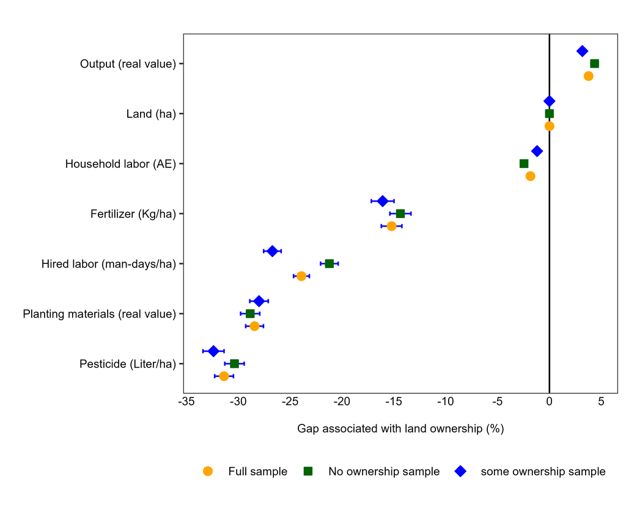

#### Figure 2. The association between farmland ownership and farm productivity from 1991-2017

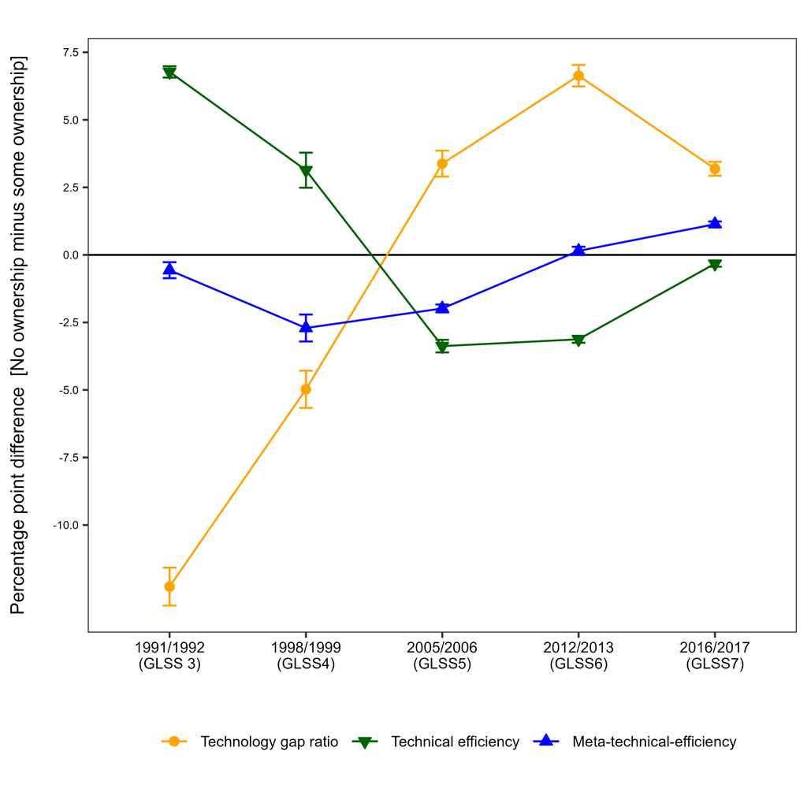

#### Figure 3. Farmland ownership parity in crop production technology adoption and technical efficiency by farmer gender, age, and education in Ghana (1991-2017)

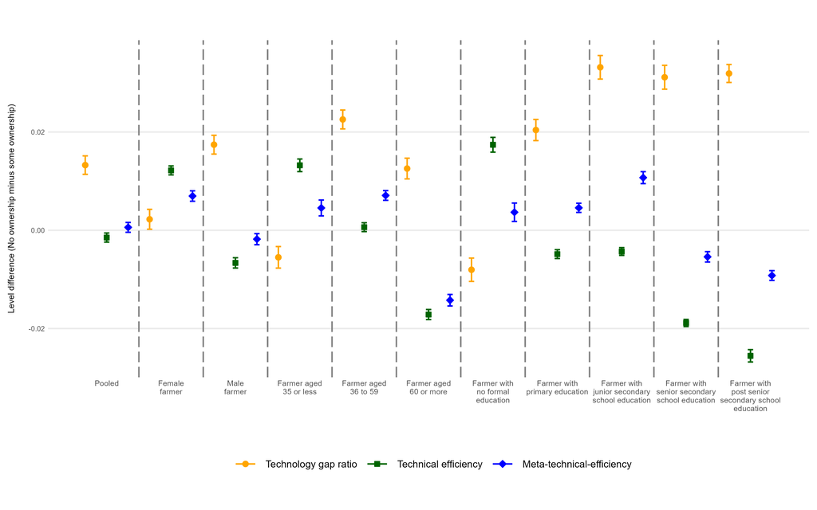

#### Figure 4. Farmland ownership parity in crop production technology adoption and technical efficiency by major crops and administrative regions in Ghana (1991-2017)

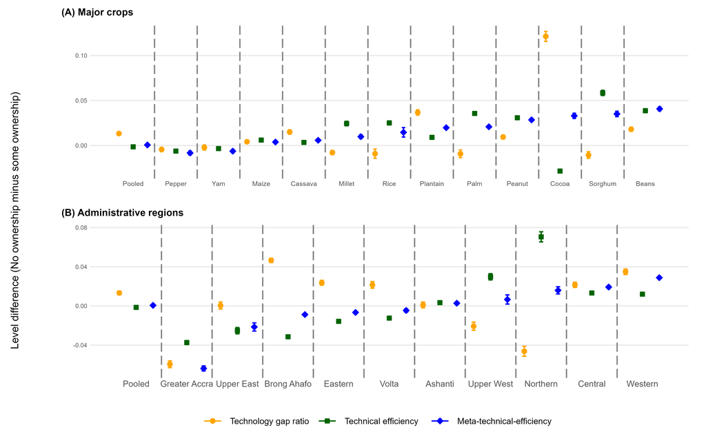

# Supplementary material

## Note S1. Drivers of technical inefficiency

Table S7 reports the covariates entering the inefficiency term, estimated on the naive national frontier, on each group-specific frontier, and on the matched and unmatched meta-frontiers. A positive coefficient moves the farm away from its efficient frontier; age and education enter in logs and are therefore elasticities. Three features of that table bear on how the ownership results in Section 5 should be read.

The first concerns gender. On all three single-technology frontiers (the naive national frontier and both group-specific frontiers), being a female farmer is associated with significantly greater inefficiency, and the coefficient is larger among non-owners than among owners. This is the most consistent farmer-level result in the table, and it is worth stating plainly that it does not disappear once ownership is held constant: whatever it reflects, it is not a by-product of women being less likely to own the land they farm.

The second concerns what is absent. Extension contact and mechanization carry no significant coefficient on any frontier, in either direction, and neither does age or crop diversification. Credit access is significant on the naive frontier and among owners, but with a positive sign: farmers with credit sit further from the frontier, not closer. We do not read this causally. Credit in these rounds reaches a small minority of farmers (Table 1), is not randomly assigned, and is plausibly sought by farms already under production stress; the sign is as consistent with selection into borrowing as with any effect of borrowing on performance.

The third concerns the meta-frontier columns, where no covariate reaches conventional significance and the jackknife standard errors are substantially larger than on the single-technology frontiers. The natural reading is that once technology heterogeneity between ownership groups is modelled separately, rather than absorbed into a single national frontier, farmer attributes explain little of the residual inefficiency, the same conflation the meta-frontier framework exists to resolve, and part of why this paper reports technology gap ratios and technical efficiency separately rather than as a single productivity index. That reading should be held loosely. The meta-frontier estimates are imprecise enough that the table cannot distinguish small effects from none, and the nulls there are better described as uninformative than as evidence of no relationship.

One caution applies throughout. The inefficiency model is estimated jointly with the frontier, so its coefficients are conditional on the frontier specification. Figure S2 shows that the assumed distribution of the inefficiency term is the dimension to which the aggregate ownership results are most sensitive; the signs reported here are stable across the matching and functional-form dimensions and should not be assumed robust to distributional choice.

#### Table S0. Construction of the farmland tenure indicators from the GLSS Section 8b plot rosters

| Survey round | Census frame | Source variables | Question wording | Response options | Mapping / comparability |
| --- | --- | --- | --- | --- | --- |
| GLSS3 (1991/92) | 1984 PHC | Part B, Section 8b plot roster, S8B.DTA; q6 (ownership), q7 (rights), q9 (acquisition), q11 (sharecrop), q4/q4c (size/unit) | Q6: "Is the farm owned by the household? PROBE IF HE HAS TITLE DEED" (non-owners skip to Q9). Q7: right to sell the farm or use it as collateral security. Q9: "How did you obtain the use of the land?"… | Ownership: Yes with deed 1; Yes without deed 2; No 3. Rights: Sell 1; Security 2; Both 3; No right 4. Acquisition: Rented for cash or kind 1; Sharecropped by household 2; Used free of charge 3; Distri… | Owned with documentation; owned without documentation; not owned. Rights as listed. Acquisition: rented; sharecropped; free; kinship. NO purchase option. File carries no variable or value labels; code… |
| GLSS4 (1998/99) | 1984 PHC | Part B, Section 8b plot roster, SEC8B.DTA; q5 (ownership), q6 (rights), q8 (acquisition), q10 (sharecrop), q4a/q4b (size/unit) | Q5: "Is the farm owned by the household?" (non-owners skip to Q8). Q6: right to sell the farm or use it as collateral security. Q8: "How did you obtain the land?" Q10: proportion of crops to the landl… | Ownership: Yes with deed 1; Yes without deed 2; No 3. Rights: Sell 1; Security 2; Both 3; No right 4. Acquisition: Rented for cash or kind 1; Sharecropped by household 2; Use free of charge 3; Distrib… | As GLSS3. NO purchase option. The GLSS3 title-deed probe is absent from this wave onward. File carries variable labels but no value labels; codes verified against G4QPartB.pdf. |
| GLSS5 (2005/06) | 2000 PHC | Part B, Section 8b plot roster, sec8b.dta; q5 (ownership), q6 (rights), q8 (acquisition), q10 (sharecrop), q4a/q4b (size/unit) | Q5: "Is the farm owned by the household?" (non-owners skip to Q8). Q6: household has right to sell land or use as collateral. Q8: "How was land obtained?" Q10: proportion of crops to landlord. | Ownership: yes with deed 1; yes without deed 2; no 3. Rights: sell 1; security 2; both 3; no right 4. Acquisition: bought 1; rented for cash or in kind 2; sharecropped by household 3; use free of char… | Purchase first observable in this wave. Unit 'plot' added. Sharecrop support narrower than GLSS6/7 (no 3/4, 1/10, 1/20 or 0). |
| GLSS6 (2012/13) | 2010 PHC | Part B, Section 8b plot roster, sec8b.dta; q5 (ownership), q6 (rights), q8 (acquisition), q10 (sharecrop), q4a/q4b (size/unit) | Q5: "Is farm owned by household?" (non-owners skip to Q8). Q6: household has right to sell farm or use as collateral. Q8: "How was land obtained?" Q10: proportion of crops to landlord. | Ownership: yes with deed 1; yes without deed 2; no 3. Rights: sell 1; security 2; both 3; no right 4. Acquisition: bought 1; rented for cash or in kind 2; sharecropped by household 3; use free of char… | Unit 'hectare' added and left unconverted. Full sharecrop support. |
| GLSS7 (2016/17) | 2010 PHC | Part B, Section 8b plot roster, g7sec8b.dta; q5 (ownership), q6 (rights), q8 (acquisition), q10 (sharecrop), q4a/q4b (size/unit) | Q5: "Is farm owned by holder?" (non-owners skip to Q8). Q6: holder has right to sell farm or use as collateral security. Q8: "How did holder obtain the land?" Q10: proportion of crops to landlord. | Ownership: Yes with deed 1; Yes without deed 2; No 3. Rights: Sell 1; Security 2; Both 3; No right 4. Acquisition: Bought 1; Rented for cash or in kind 2; Sharecropped by household 3; Use free of char… | Acquisition option 'Inherited' unique to this wave and folded into kinship; it is the larger of the two components (4,699 vs 2,037 plots), so kinship is not wave-comparable. Referent shifts from 'hous… |

Farmer-level tenure is the category holding the largest share of cultivated area across the farmer's plots, not 'owns any land'. Ties resolve toward the more secure category and affect under 0.5% of farmers in every wave.  
Non-owners are skipped past the rights question in every wave, so 'no right' is assigned to them by construction rather than measured.  
Purchase is not a response option in GLSS3 or GLSS4; 'inherited' is unique to GLSS7 and is folded into kinship.  
Poles and Ropes are local, respondent-defined units. GSS instructs interviewers to record them as given and publishes no conversion; the hectare equivalents used here are analyst assumptions covering 11-36% of plots by wave.  
GSS drew GLSS3 and GLSS4 from the 1984 census frame, which the GLSS4 report describes as 'quite old' and 'inadequate', and GLSS5 onward from the 2000 Population and Housing Census frame. Each wave is internally representative; comparisons spanning the GLSS4/GLSS5 boundary are not drawn from a common population.  
Data source: Ghana Living Standards Survey [waves 3-7], Part B Section 8b, and the corresponding questionnaire instruments.

#### Table S1. Farmland ownership status amongst Ghanaian crop farmers (2012-2017)

| Crop | Headcount ratio over 2012/13-2016/17 Not owned | Headcount ratio over 2012/13-2016/17 Owned without documentation | Headcount ratio over 2012/13-2016/17 Owned with documentation |
| --- | --- | --- | --- |
| Banana | 0.421 (0.496) | 0.336 (0.475) | 0.243 (0.431) |
| Cocoyam | 0.409 (0.492) | 0.403 (0.491) | 0.188 (0.391) |
| Cassava | 0.406 (0.491) | 0.407 (0.491) | 0.188 (0.390) |
| Plantain | 0.397 (0.489) | 0.383 (0.486) | 0.219 (0.414) |
| Palm | 0.384 (0.487) | 0.397 (0.490) | 0.219 (0.414) |
| Cocoa | 0.360 (0.480) | 0.376 (0.484) | 0.264 (0.441) |
| Eggplant | 0.359 (0.481) | 0.413 (0.494) | 0.228 (0.421) |
| Maize | 0.338 (0.473) | 0.494 (0.500) | 0.168 (0.374) |
| Pepper | 0.328 (0.470) | 0.488 (0.500) | 0.184 (0.387) |
| Okra | 0.325 (0.469) | 0.552 (0.498) | 0.124 (0.330) |
| Tomato | 0.312 (0.464) | 0.551 (0.498) | 0.136 (0.343) |
| Yam | 0.306 (0.461) | 0.548 (0.498) | 0.146 (0.353) |
| Peanut | 0.281 (0.449) | 0.604 (0.489) | 0.115 (0.319) |
| Rice | 0.260 (0.439) | 0.582 (0.493) | 0.158 (0.365) |
| Millet | 0.223 (0.416) | 0.577 (0.494) | 0.200 (0.400) |
| Beans | 0.205 (0.404) | 0.630 (0.483) | 0.164 (0.371) |
| Sorghum | 0.202 (0.401) | 0.626 (0.484) | 0.173 (0.378) |
| All crops listed | 0.327 (0.469) | 0.493 (0.500) | 0.180 (0.384) |
| Change in headcount ratio, 2012/13 to 2016/17 (pp) |  |  |  |
| Cocoyam | 1.64 | 4.60 | -6.24 |
| Rice | 0.29 | 16.39 | -16.68 |
| Okra | 0.27 | 14.50 | -14.77 |
| Beans | 0.22 | 15.09 | -15.31 |
| Millet | -1.86 | 12.46 | -10.60 |
| Maize | -2.92 | 6.72 | -3.79 |
| Plantain | -3.10 | 4.63 | -1.53 |
| Cassava | -4.73 | 4.75 | -0.02 |
| Sorghum | -5.57 | 13.38 | -7.81 |
| Eggplant | -6.80 | -0.68 | 7.47 |
| Yam | -9.13 | 0.77 | 8.36 |
| Cocoa | -9.83 | 10.73 | -0.91 |
| Pepper | -11.41 | 21.13 | -9.72 |
| Banana | -13.08 | 4.43 | 8.64 |
| Tomato | -13.66 | 10.98 | 2.68 |
| Peanut | -13.73 | 15.93 | -2.20 |
| Palm | -16.20 | 2.87 | 13.33 |
| All crops listed | -9.74 | 12.21 | -2.47 |

Cells are headcount ratios over 2012/13-2016/17.  
Restricted to GLSS6-GLSS7 for comparability, not availability: all five rounds administer the ownership detail modules (Table S0), but the acquisition categories and sharecropping bins are not comparable across earlier rounds, and GLSS3-GLSS4 were fielded on the 1984 census frame.  
Data source: Ghana Living Standards Survey [waves 6-7].

#### Table S2. Farmland mode of acquisition amongst Ghanaian crop farmers (2012-2017)

| Crop | Headcount ratio over 2012/13-2016/17 Distributed by village/family | Headcount ratio over 2012/13-2016/17 Use free of charge | Headcount ratio over 2012/13-2016/17 Sharecropping | Headcount ratio over 2012/13-2016/17 Rented (cash or in kind) | Headcount ratio over 2012/13-2016/17 Purchased |
| --- | --- | --- | --- | --- | --- |
| Sorghum | 0.819 (0.385) | 0.158 (0.365) | 0.004 (0.062) | 0.014 (0.119) | 0.005 (0.069) |
| Millet | 0.817 (0.387) | 0.154 (0.361) | 0.004 (0.059) | 0.020 (0.139) | 0.006 (0.075) |
| Beans | 0.770 (0.421) | 0.156 (0.363) | 0.021 (0.144) | 0.044 (0.205) | 0.010 (0.098) |
| Rice | 0.757 (0.429) | 0.171 (0.376) | 0.033 (0.179) | 0.029 (0.167) | 0.011 (0.103) |
| Peanut | 0.705 (0.456) | 0.229 (0.420) | 0.013 (0.112) | 0.047 (0.211) | 0.007 (0.084) |
| Maize | 0.624 (0.484) | 0.186 (0.389) | 0.101 (0.301) | 0.068 (0.252) | 0.021 (0.143) |
| Yam | 0.623 (0.485) | 0.219 (0.414) | 0.047 (0.211) | 0.096 (0.295) | 0.015 (0.122) |
| Cocoyam | 0.613 (0.487) | 0.103 (0.305) | 0.202 (0.402) | 0.038 (0.193) | 0.043 (0.202) |
| Plantain | 0.600 (0.490) | 0.096 (0.295) | 0.221 (0.415) | 0.034 (0.180) | 0.049 (0.217) |
| Tomato | 0.599 (0.491) | 0.121 (0.327) | 0.107 (0.309) | 0.158 (0.365) | 0.015 (0.121) |
| Palm | 0.599 (0.491) | 0.063 (0.243) | 0.262 (0.440) | 0.019 (0.135) | 0.058 (0.233) |
| Okra | 0.588 (0.493) | 0.195 (0.396) | 0.059 (0.236) | 0.150 (0.358) | 0.008 (0.090) |
| Pepper | 0.581 (0.494) | 0.174 (0.379) | 0.120 (0.325) | 0.115 (0.319) | 0.011 (0.103) |
| Eggplant | 0.569 (0.497) | 0.108 (0.311) | 0.144 (0.352) | 0.114 (0.318) | 0.066 (0.249) |
| Cocoa | 0.562 (0.496) | 0.072 (0.258) | 0.281 (0.450) | 0.012 (0.110) | 0.073 (0.261) |
| Cassava | 0.557 (0.497) | 0.163 (0.369) | 0.176 (0.381) | 0.072 (0.259) | 0.032 (0.176) |
| Banana | 0.523 (0.502) | 0.112 (0.317) | 0.308 (0.464) | 0.019 (0.136) | 0.037 (0.191) |
| All crops listed | 0.610 (0.488) | 0.168 (0.374) | 0.134 (0.341) | 0.060 (0.237) | 0.028 (0.166) |
| Change in headcount ratio, 2012/13 to 2016/17 (pp) |  |  |  |  |  |
| Pepper | 9.29 | -4.05 | -4.82 | -0.93 | 0.51 |
| Cocoyam | 7.35 | 3.45 | -10.98 | 1.35 | -1.17 |
| Banana | 3.85 | 2.78 | -4.10 | -0.84 | -1.68 |
| Cocoa | 3.45 | 3.45 | -6.81 | -1.16 | 1.07 |
| Palm | 2.64 | -0.05 | -5.51 | -1.46 | 4.38 |
| Cassava | -0.91 | 1.48 | -1.27 | 0.10 | 0.60 |
| Plantain | -1.08 | 2.71 | -2.56 | 0.80 | 0.12 |
| Eggplant | -1.37 | -2.79 | 3.80 | -1.28 | 1.64 |
| Maize | -2.52 | 3.10 | -0.04 | -1.36 | 0.83 |
| Tomato | -3.21 | -0.89 | -7.50 | 9.55 | 2.05 |
| Okra | -3.70 | -2.62 | 3.79 | 1.57 | 0.95 |
| Peanut | -4.30 | 6.19 | -0.33 | -2.39 | 0.83 |
| Rice | -4.88 | 6.35 | -1.93 | -0.00 | 0.46 |
| Sorghum | -5.11 | 5.32 | -0.60 | -0.23 | 0.62 |
| Yam | -5.38 | -3.50 | 1.18 | 6.24 | 1.45 |
| Millet | -5.42 | 5.35 | -0.38 | -0.11 | 0.56 |
| Beans | -5.50 | 2.42 | 1.33 | 0.85 | 0.89 |
| All crops listed | 0.75 | 3.09 | -4.16 | -0.61 | 0.93 |

Cells are headcount ratios over 2012/13-2016/17.  
Restricted to GLSS6-GLSS7 for comparability, not availability: all five rounds administer the ownership detail modules (Table S0), but the acquisition categories and sharecropping bins are not comparable across earlier rounds, and GLSS3-GLSS4 were fielded on the 1984 census frame.  
Data source: Ghana Living Standards Survey [waves 6-7].

#### Table S3. Farmland ownership rights amongst Ghanaian crop farmers (2012-2017)

| Crop | Headcount ratio over 2012/13-2016/17 No rights | Headcount ratio over 2012/13-2016/17 Can be used as collateral security | Headcount ratio over 2012/13-2016/17 Can be sold | Headcount ratio over 2012/13-2016/17 Can be used as collateral security and sold |
| --- | --- | --- | --- | --- |
| Peanut | 0.707 (0.455) | 0.022 (0.148) | 0.023 (0.151) | 0.247 (0.432) |
| Beans | 0.676 (0.468) | 0.010 (0.101) | 0.021 (0.143) | 0.293 (0.455) |
| Rice | 0.663 (0.473) | 0.021 (0.143) | 0.023 (0.151) | 0.293 (0.455) |
| Maize | 0.659 (0.474) | 0.021 (0.143) | 0.048 (0.214) | 0.272 (0.445) |
| Sorghum | 0.652 (0.476) | 0.011 (0.103) | 0.029 (0.167) | 0.309 (0.462) |
| Millet | 0.650 (0.477) | 0.011 (0.106) | 0.025 (0.155) | 0.314 (0.464) |
| Yam | 0.637 (0.481) | 0.025 (0.156) | 0.037 (0.189) | 0.301 (0.459) |
| Okra | 0.625 (0.485) | 0.032 (0.177) | 0.024 (0.154) | 0.318 (0.466) |
| Pepper | 0.615 (0.487) | 0.062 (0.241) | 0.034 (0.182) | 0.289 (0.454) |
| Banana | 0.607 (0.491) | 0.009 (0.097) | 0.065 (0.248) | 0.318 (0.468) |
| Tomato | 0.607 (0.489) | 0.033 (0.179) | 0.029 (0.169) | 0.331 (0.471) |
| Cassava | 0.588 (0.492) | 0.035 (0.183) | 0.059 (0.236) | 0.318 (0.466) |
| Eggplant | 0.575 (0.496) | 0.012 (0.109) | 0.030 (0.171) | 0.383 (0.488) |
| Palm | 0.534 (0.499) | 0.032 (0.175) | 0.095 (0.293) | 0.340 (0.474) |
| Plantain | 0.525 (0.500) | 0.036 (0.186) | 0.062 (0.242) | 0.377 (0.485) |
| Cocoyam | 0.502 (0.501) | 0.067 (0.250) | 0.049 (0.215) | 0.383 (0.487) |
| Cocoa | 0.463 (0.499) | 0.055 (0.227) | 0.083 (0.275) | 0.399 (0.490) |
| All crops listed | 0.604 (0.489) | 0.030 (0.170) | 0.051 (0.220) | 0.315 (0.465) |
| Change in headcount ratio, 2012/13 to 2016/17 (pp) |  |  |  |  |
| Rice | 8.14 | 0.95 | 1.57 | -10.66 |
| Beans | 8.05 | 0.22 | -0.82 | -7.45 |
| Millet | 4.29 | -0.02 | -0.11 | -4.16 |
| Sorghum | -1.19 | 0.29 | 1.45 | -0.55 |
| Maize | -4.13 | 0.49 | 4.06 | -0.41 |
| Banana | -5.82 | -2.38 | -0.99 | 9.19 |
| Plantain | -8.98 | 1.78 | 5.11 | 2.09 |
| Cocoyam | -9.01 | 8.19 | 3.21 | -2.38 |
| Cocoa | -9.96 | 3.22 | 5.44 | 1.29 |
| Peanut | -10.75 | 2.27 | 0.72 | 7.75 |
| Cassava | -10.80 | 0.76 | 6.56 | 3.49 |
| Okra | -12.10 | -0.30 | -2.06 | 14.46 |
| Pepper | -21.86 | 10.30 | 1.17 | 10.39 |
| Eggplant | -22.40 | 0.53 | 5.07 | 16.80 |
| Yam | -24.95 | 0.44 | 3.42 | 21.08 |
| Palm | -31.38 | -0.02 | 8.37 | 23.03 |
| Tomato | -36.34 | 1.96 | 4.11 | 30.27 |
| All crops listed | -9.53 | 1.32 | 3.53 | 4.68 |

Cells are headcount ratios over 2012/13-2016/17.  
Restricted to GLSS6-GLSS7 for comparability, not availability: all five rounds administer the ownership detail modules (Table S0), but the acquisition categories and sharecropping bins are not comparable across earlier rounds, and GLSS3-GLSS4 were fielded on the 1984 census frame.  
Data source: Ghana Living Standards Survey [waves 6-7].

#### Table S4. Farmland sharecropping agreements amongst Ghanaian crop farmers (2012-2017)

| Crop | Headcount ratio over 2012/13-2016/17 0 | Headcount ratio over 2012/13-2016/17 1-49 | Headcount ratio over 2012/13-2016/17 50-100 |
| --- | --- | --- | --- |
| Sorghum | 0.985 (0.120) | 0.012 (0.109) | 0.003 (0.051) |
| Millet | 0.981 (0.137) | 0.012 (0.110) | 0.007 (0.082) |
| Peanut | 0.966 (0.182) | 0.020 (0.141) | 0.014 (0.118) |
| Beans | 0.953 (0.212) | 0.025 (0.157) | 0.022 (0.146) |
| Rice | 0.939 (0.239) | 0.036 (0.187) | 0.025 (0.155) |
| Yam | 0.898 (0.303) | 0.030 (0.172) | 0.072 (0.258) |
| Okra | 0.870 (0.336) | 0.039 (0.193) | 0.091 (0.288) |
| Maize | 0.860 (0.347) | 0.066 (0.248) | 0.074 (0.261) |
| Pepper | 0.825 (0.380) | 0.062 (0.241) | 0.114 (0.318) |
| Tomato | 0.794 (0.405) | 0.048 (0.214) | 0.158 (0.365) |
| Eggplant | 0.784 (0.412) | 0.078 (0.269) | 0.138 (0.346) |
| Cassava | 0.777 (0.417) | 0.076 (0.264) | 0.148 (0.355) |
| Plantain | 0.724 (0.447) | 0.071 (0.257) | 0.205 (0.404) |
| Cocoyam | 0.706 (0.456) | 0.055 (0.228) | 0.239 (0.427) |
| Cocoa | 0.659 (0.474) | 0.078 (0.268) | 0.263 (0.440) |
| Palm | 0.653 (0.476) | 0.115 (0.319) | 0.232 (0.422) |
| Banana | 0.598 (0.493) | 0.131 (0.339) | 0.271 (0.447) |
| All crops listed | 0.821 (0.384) | 0.071 (0.257) | 0.108 (0.311) |
| Change in headcount ratio, 2012/13 to 2016/17 (pp) |  |  |  |
| Banana | 12.23 | -5.90 | -6.34 |
| Cocoa | 8.34 | -5.06 | -3.28 |
| Cocoyam | 7.31 | -5.47 | -1.84 |
| Rice | 1.82 | -3.28 | 1.46 |
| Palm | 1.78 | -3.51 | 1.73 |
| Plantain | 1.07 | -2.65 | 1.58 |
| Sorghum | 0.31 | -0.14 | -0.17 |
| Millet | 0.24 | -1.13 | 0.89 |
| Peanut | -0.65 | -0.72 | 1.38 |
| Cassava | -1.34 | -1.67 | 3.01 |
| Maize | -1.65 | -1.22 | 2.87 |
| Beans | -2.46 | -0.56 | 3.02 |
| Pepper | -2.66 | -4.53 | 7.20 |
| Tomato | -7.50 | -3.57 | 11.07 |
| Yam | -9.44 | 1.67 | 7.77 |
| Okra | -11.05 | -1.43 | 12.48 |
| Eggplant | -14.46 | 2.16 | 12.30 |
| All crops listed | 2.57 | -3.10 | 0.52 |

Cells are headcount ratios over 2012/13-2016/17.  
Restricted to GLSS6-GLSS7 for comparability, not availability: all five rounds administer the ownership detail modules (Table S0), but the acquisition categories and sharecropping bins are not comparable across earlier rounds, and GLSS3-GLSS4 were fielded on the 1984 census frame.  
Data source: Ghana Living Standards Survey [waves 6-7].

#### Table S5. Mean meta stochastic frontier analysis results for Ghanaian crop producers from 1991-2017

|  | Naïve national frontier | Group frontier No land ownership | Group frontier Some land ownership |  | Meta-frontier Matched | Meta-frontier Unmatched |
| --- | --- | --- | --- | --- | --- | --- |
| Production function |  |  |  |  |  |  |
| Land [lnI1] | 0.756*** (0.060) | 0.721*** (0.065) | 0.780*** (0.067) |  | 0.727*** (0.062) | 0.729*** (0.049) |
| Planting material [lnI2] | 0.056*** (0.008) | 0.046*** (0.007) | 0.061*** (0.016) |  | 0.052*** (0.005) | 0.052*** (0.007) |
| Family labor [lnI3] | 0.138*** (0.042) | 0.087 (0.062) | 0.203*** (0.065) |  | 0.102 (0.073) | 0.109** (0.046) |
| Hired labor [lnI4] | 0.030*** (0.008) | 0.019*** (0.007) | 0.035*** (0.012) |  | 0.027*** (0.009) | 0.030*** (0.009) |
| Fertilizer [lnI5] | 0.020** (0.008) | 0.022*** (0.008) | 0.019* (0.011) |  | 0.019* (0.010) | 0.018* (0.010) |
| Pesticide [lnI6] | 0.037*** (0.008) | 0.041*** (0.011) | 0.031* (0.018) |  | 0.037*** (0.007) | 0.035*** (0.010) |
| 1/2 * lnI1 * lnI1 | 0.000 (0.065) | 0.034 (0.046) | -0.002 (0.077) |  | 0.032 (0.056) | 0.011 (0.062) |
| lnI1*lnI2 | 0.000 (0.000) | -0.001 (0.002) | 0.000 (0.000) |  | -0.000 (0.001) | 0.000 (0.002) |
| lnI1*lnI3 | -0.047*** (0.014) | -0.031 (0.021) | -0.057** (0.029) |  | -0.041** (0.020) | -0.039** (0.018) |
| lnI1*lnI4 | 0.000 (0.000) | -0.000 (0.000) | -0.000 (0.000) |  | -0.000 (0.000) | 0.000 (0.000) |
| lnI1*lnI6 | 0.000 (0.001) | 0.001 (0.002) | 0.001 (0.001) |  | 0.001 (0.002) | 0.001 (0.002) |
| lnI1*lnI5 | -0.000 (0.000) | -0.000 (0.001) | -0.000 (0.000) |  | -0.000 (0.000) | -0.001 (0.001) |
| 1/2 * lnI2 * lnI2 | 0.005*** (0.001) | 0.004*** (0.001) | 0.005*** (0.001) |  | 0.004*** (0.000) | 0.004*** (0.001) |
| lnI2*lnI3 | -0.000 (0.000) | 0.001 (0.002) | -0.001 (0.001) |  | -0.000 (0.001) | -0.000 (0.001) |
| lnI2*lnI4 | -0.000 (0.000) | 0.000 (0.000) | -0.000 (0.000) |  | -0.000 (0.000) | -0.000 (0.000) |
| lnI2*lnI6 | -0.000 (0.000) | -0.000 (0.000) | -0.000 (0.000) |  | -0.000 (0.000) | -0.000 (0.000) |
| lnI2*lnI5 | -0.000 (0.000) | -0.000 (0.000) | 0.000 (0.000) |  | -0.000 (0.000) | -0.000 (0.000) |
| 1/2 * lnI3 * lnI3 | 0.038* (0.023) | 0.040 (0.037) | 0.021 (0.024) |  | 0.050 (0.040) | 0.052* (0.029) |
| lnI3*lnI4 | 0.000 (0.000) | 0.000 (0.000) | 0.000 (0.000) |  | 0.001 (0.001) | 0.000 (0.001) |
| lnI3*lnI6 | -0.000 (0.000) | -0.002 (0.003) | 0.002 (0.006) |  | -0.002 (0.003) | -0.001 (0.001) |
| lnI3*lnI5 | 0.000 (0.000) | -0.000 (0.000) | -0.001 (0.001) |  | -0.001 (0.002) | -0.000 (0.001) |
| 1/2 * lnI4 * lnI4 | 0.003*** (0.001) | 0.002*** (0.001) | 0.003*** (0.001) |  | 0.002*** (0.001) | 0.002*** (0.001) |
| lnI4*lnI6 | -0.000 (0.000) | 0.000 (0.000) | 0.000 (0.000) |  | 0.000 (0.000) | 0.000 (0.000) |
| lnI4*lnI5 | -0.000 (0.000) | 0.000 (0.000) | 0.000 (0.000) |  | 0.000 (0.000) | -0.000 (0.000) |
| 1/2 * lnI5 * lnI5 | 0.002** (0.001) | 0.002** (0.001) | 0.001 (0.001) |  | 0.001 (0.001) | 0.001 (0.001) |
| lnI5*lnI6 | -0.000 (0.000) | -0.000 (0.000) | 0.000 (0.000) |  | -0.000 (0.000) | -0.000 (0.000) |
| 1/2 * lnI6 * lnI6 | 0.003*** (0.001) | 0.003* (0.002) | 0.002 (0.002) |  | 0.002* (0.001) | 0.002 (0.002) |
| Proportion of area under listed crop (base=maize) |  |  |  |  |  |  |
| Cassava | -0.125 (0.300) | 0.238 (0.484) | -0.252 (0.308) |  | -0.074 (0.381) | -0.128 (0.342) |
| Peanut | -0.061 (0.329) | 0.288 (0.498) | -0.180 (0.349) |  | -0.032 (0.397) | -0.067 (0.369) |
| Plantain | -0.124 (0.296) | 0.234 (0.480) | -0.244 (0.313) |  | -0.076 (0.375) | -0.126 (0.339) |
| Rice | -0.075 (0.316) | 0.499 (0.728) | -0.231 (0.344) |  | 0.089 (0.534) | -0.068 (0.366) |
| Millet | -0.058 (0.323) | 0.265 (0.477) | -0.154 (0.343) |  | -0.023 (0.385) | -0.060 (0.367) |
| Sorghum | -0.060 (0.330) | 0.274 (0.501) | -0.061 (0.525) |  | 0.028 (0.448) | -0.051 (0.385) |
| Beans | -0.093 (0.314) | 0.253 (0.499) | -0.113 (0.443) |  | -0.010 (0.420) | -0.085 (0.366) |
| Yam | -0.157 (0.316) | 0.221 (0.490) | -0.407 (0.422) |  | -0.187 (0.468) | -0.136 (0.338) |
| Cocoa | 0.375 (0.398) | 0.690 (0.591) | 0.507 (0.325) |  | 0.550* (0.328) | 0.508 (0.337) |
| Palm | -0.117 (0.248) | 0.263 (0.453) | -0.285 (0.259) |  | -0.070 (0.331) | -0.113 (0.282) |
| Pepper | -0.175 (0.266) | 0.224 (0.483) | -0.522 (0.413) |  | -0.102 (0.365) | -0.176 (0.312) |
| Other | -0.122 (0.293) | 0.245 (0.482) | -0.246 (0.311) |  | -0.068 (0.377) | -0.122 (0.340) |
| Ecological zone [base = Coastal Savannah] |  |  |  |  |  |  |
| Forest | 0.386* (0.231) | 0.305 (0.226) | 0.330 (0.277) |  | 0.370** (0.180) | 0.374* (0.213) |
| Guinea Savanah | -0.139 (0.539) | -0.117 (0.581) | -0.304 (0.325) |  | -0.157 (0.586) | -0.151 (0.597) |
| Sudan Savanah | -0.528 (0.420) | -0.431 (0.453) | -0.627 (0.458) |  | -0.487 (0.464) | -0.522 (0.458) |
| Transitional | 0.134 (0.249) | 0.071 (0.224) | 0.157 (0.261) |  | 0.106 (0.242) | 0.100 (0.255) |
| Intercept | 6.905*** (0.551) | 6.601*** (0.656) | 6.954*** (0.545) |  | 7.045*** (0.634) | 7.124*** (0.615) |
| Production risk function |  |  |  |  |  |  |
| Intercept | -0.689*** (0.155) | -0.771*** (0.278) | -0.569*** (0.141) |  | -4.915*** (0.838) | -5.449*** (1.210) |

Significance levels: * p<0.10, ** p<0.05, *** p<0.01. Jackknife standard errors in parentheses.  
Fertilizer is lnI5 and pesticide is lnI6, following input_variables order in 004_MSF_land_tenure_study.R.  
Data source: Ghana Living Standards Survey [waves 3-7].

#### Table S6. Parity in technology level and technical efficiency by farmland ownership details in Ghana (1991-2017) - unmatched estimates

|  | Level difference (unmatched estimates) Technology gap ratio (TGR) | Level difference (unmatched estimates) Pure farmer technical efficiency (TE) | Level difference (unmatched estimates) Meta-frontier technical efficiency (MTE) |
| --- | --- | --- | --- |
| GLSS3-GLSS7 |  |  |  |
| Land ownership status |  |  |  |
| Owned without documentation | 0.028*** (0.006) | 0.048*** (0.002) | 0.046*** (0.004) |
| Owned with documentation | 0.024 (0.024) | -0.022 (0.024) | -0.010** (0.005) |
| Farmland ownership rights |  |  |  |
| Can be used as collateral security | -0.050*** (0.005) | -0.002 (0.003) | -0.031*** (0.006) |
| Can be sold | -0.033*** (0.006) | -0.023*** (0.007) | -0.041*** (0.009) |
| Can be used as collateral security and sold | -0.008 (0.006) | -0.009*** (0.003) | -0.013*** (0.004) |
| GLSS7 |  |  |  |
| Land ownership status |  |  |  |
| Owned without documentation | 0.024*** (0.004) | 0.049*** (0.001) | 0.058*** (0.003) |
| Owned with documentation | 0.073*** (0.003) | 0.024*** (0.002) | 0.062*** (0.002) |
| Farmland ownership rights |  |  |  |
| Can be used as collateral security | -0.080*** (0.005) | -0.084*** (0.004) | -0.125*** (0.002) |
| Can be sold | -0.059*** (0.004) | 0.010** (0.004) | -0.021*** (0.002) |
| Can be used as collateral security and sold | 0.004*** (0.001) | 0.017*** (0.001) | 0.018*** (0.001) |
| GLSS6 |  |  |  |
| Land ownership status |  |  |  |
| Owned without documentation | 0.050*** (0.009) | 0.057*** (0.005) | 0.070*** (0.004) |
| Owned with documentation | 0.063*** (0.005) | -0.023*** (0.001) | 0.008*** (0.002) |
| Farmland ownership rights |  |  |  |
| Can be used as collateral security | 0.038*** (0.003) | -0.129*** (0.003) | -0.097*** (0.004) |
| Can be sold | -0.099*** (0.003) | 0.037*** (0.002) | -0.019*** (0.001) |
| Can be used as collateral security and sold | -0.004 (0.004) | -0.004 (0.010) | -0.004 (0.006) |
| GLSS5 |  |  |  |
| Land ownership status |  |  |  |
| Owned without documentation | 0.135*** (0.013) | 0.046*** (0.004) | 0.095*** (0.006) |
| Owned with documentation | -0.004 (0.006) | 0.003 (0.002) | -0.001 (0.002) |
| Farmland ownership rights |  |  |  |
| Can be used as collateral security | 0.001 (0.009) | 0.009 (0.007) | 0.009 (0.008) |
| Can be sold | -0.001 (0.011) | -0.015*** (0.005) | -0.015 (0.009) |
| Can be used as collateral security and sold | 0.001 (0.022) | -0.032*** (0.005) | -0.032** (0.013) |

Significance levels: * p<0.10, ** p<0.05, *** p<0.01. Jackknife standard errors in parentheses.  
Unmatched-sample counterpart of Table 4: level difference of each category relative to farmers in the reference category (not owned; no rights), estimated on that category's own meta-stochastic frontier. Scores are sampling-weighted means.  
Because these are unmatched, the comparison groups are not balanced on observables; read alongside Table 4 rather than instead of it.  
Meta Stochastic Frontier Analysis jointly performed on Ghana Living Standards Survey [waves 3-7].

#### Table S7. Determinants of crop production technical inefficiency and land-ownership-driven technology gaps in Ghana (1991-2017)

|  | Naïve national frontier | Group frontier No land ownership | Group frontier Some land ownership |  | Meta-frontier Matched | Meta-frontier Unmatched |
| --- | --- | --- | --- | --- | --- | --- |
| Female farmer (dummy) | 0.318*** (0.060) | 0.397*** (0.061) | 0.243*** (0.079) |  | 0.203 (0.239) | 0.172 (0.149) |
| Age (log years) | 0.110 (0.081) | 0.115 (0.128) | 0.013 (0.214) |  | -0.087 (0.610) | 0.037 (0.373) |
| Education (log years) | 0.008 (0.006) | 0.012** (0.005) | 0.001 (0.011) |  | -0.001 (0.026) | 0.018 (0.034) |
| Crop diversification (index) | 0.054 (0.376) | -0.226 (0.488) | 0.300 (0.262) |  | -0.056 (0.963) | -0.174 (0.870) |
| Mechanization (dummy) | -0.137 (0.270) | 0.172 (0.383) | -0.290 (0.340) |  | 0.453 (0.806) | -0.010 (0.207) |
| Extension (dummy) | -0.085 (0.142) | -0.109 (0.209) | -0.024 (0.133) |  | -0.220 (0.147) | -0.088 (0.156) |
| Credit (dummy) | 0.133** (0.066) | 0.120 (0.116) | 0.139** (0.066) |  | 0.097 (0.522) | 0.006 (0.384) |
| Ecological zone [base = Coastal Savannah] |  |  |  |  |  |  |
| Forest | 0.417** (0.163) | 0.344 (0.225) | 0.415* (0.250) |  | 1.885 (4.000) | 0.780 (0.847) |
| Guinea Savanah | -1.153** (0.542) | -0.842* (0.436) | -7.898 (13.173) |  | -0.435 (4.418) | -0.574 (5.336) |
| Sudan Savanah | -3.615 (2.996) | -3.026 (2.679) | -15.052 (24.600) |  | -7.903 (16.131) | -0.651 (2.423) |
| Transitional | 0.122 (0.274) | -0.004 (0.194) | 0.241 (0.248) |  | -0.082 (2.275) | -0.121 (1.081) |
| Intercept | -0.031 (0.292) | -0.002 (0.614) | 0.161 (0.938) |  | -4.503 (3.229) | -3.840* (2.294) |

Significance levels: * p<0.10, ** p<0.05, *** p<0.01. Jackknife standard errors in parentheses.  
A positive coefficient means the variable moves the farm away from its efficient frontier.  
Age and education enter the inefficiency function in logs; their coefficients are therefore elasticities, not per-year effects.  
Data source: Ghana Living Standards Survey [waves 3-7].

#### Figure S1. Covariate balancing summary

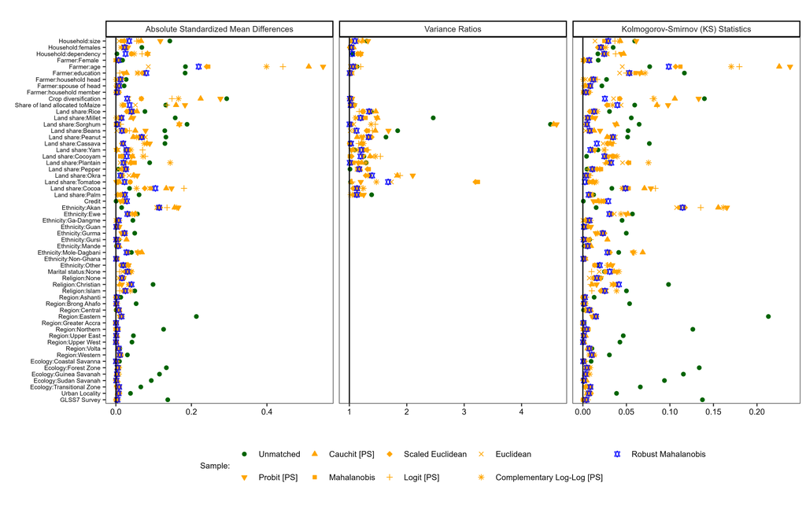

#### Figure S2. Alternative model specifications generally show a decreasing impact of land ownership on crop production output for Ghanaian farmers (1991-2017)

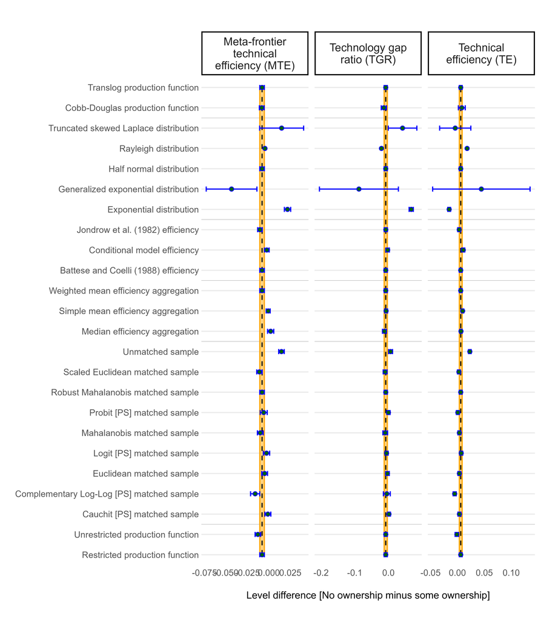